# HealthCatalyst_Assignment

```python
%matplotlib inline
import seaborn as sns
import matplotlib.pyplot as plt
import pandas as pd
from sklearn import preprocessing
from sklearn.cross_validation import train_test_split
from scipy.stats import chisquare, ks_2samp
import numpy as np
```

```python
# Reading the data into python
data=pd.read_csv("training_data.csv",header=0,skiprows=0,engine='python')
data.shape
```

```
(81414, 50)
```

```python
# printing out first 5 observations
data.head()
```

|  | encounter_id | patient_nbr | race | gender | age | weight | admission_type_id | discharge_disposition_id | admission_source_id | time_in_hospital | ... | citoglipton | insulin | glyburide-metformin | glipizide-metformin | glimepiride-pioglitazone | metformin-rosiglitazone | metformin-pioglitazone | change | diabetesMed | readmitted |
| --- | --- | --- | --- | --- | --- | --- | --- | --- | --- | --- | --- | --- | --- | --- | --- | --- | --- | --- | --- | --- | --- |
| 0 | 2278392 | 8222157 | Caucasian | Female | [0-10) | ? | 6 | 25 | 1 | 1 | ... | No | No | No | No | No | No | No | No | No | N |
| 1 | 149190 | 55629189 | Caucasian | Female | [10-20) | ? | 1 | 1 | 7 | 3 | ... | No | Up | No | No | No | No | No | Ch | Yes | N |
| 2 | 64410 | 86047875 | AfricanAmerican | Female | [20-30) | ? | 1 | 1 | 7 | 2 | ... | No | No | No | No | No | No | No | No | Yes | N |
| 3 | 500364 | 82442376 | Caucasian | Male | [30-40) | ? | 1 | 1 | 7 | 2 | ... | No | Up | No | No | No | No | No | Ch | Yes | N |
| 4 | 16680 | 42519267 | Caucasian | Male | [40-50) | ? | 1 | 1 | 7 | 1 | ... | No | Steady | No | No | No | No | No | Ch | Yes | N |

5 rows × 50 columns

```python
#Printing all the columns in the dataset
print(data.info())
```

```
<class 'pandas.core.frame.DataFrame'>
RangeIndex: 81414 entries, 0 to 81413
Data columns (total 50 columns):
encounter_id                81414 non-null int64
patient_nbr                 81414 non-null int64
race                        81414 non-null object
gender                      81414 non-null object
age                         81414 non-null object
weight                      81414 non-null object
admission_type_id           81414 non-null int64
discharge_disposition_id    81414 non-null int64
admission_source_id         81414 non-null int64
time_in_hospital            81414 non-null int64
payer_code                  81414 non-null object
medical_specialty           81414 non-null object
num_lab_procedures          81414 non-null int64
num_procedures              81414 non-null int64
num_medications             81414 non-null int64
number_outpatient           81414 non-null int64
number_emergency            81414 non-null int64
number_inpatient            81414 non-null int64
diag_1                      81414 non-null object
diag_2                      81414 non-null object
diag_3                      81414 non-null object
number_diagnoses            81414 non-null int64
max_glu_serum               81414 non-null object
A1Cresult                   81414 non-null object
metformin                   81414 non-null object
repaglinide                 81414 non-null object
nateglinide                 81414 non-null object
chlorpropamide              81414 non-null object
glimepiride                 81414 non-null object
acetohexamide               81414 non-null object
glipizide                   81414 non-null object
glyburide                   81414 non-null object
tolbutamide                 81414 non-null object
pioglitazone                81414 non-null object
rosiglitazone               81414 non-null object
acarbose                    81414 non-null object
miglitol                    81414 non-null object
troglitazone                81414 non-null object
tolazamide                  81414 non-null object
examide                     81414 non-null object
citoglipton                 81414 non-null object
insulin                     81414 non-null object
glyburide-metformin         81414 non-null object
glipizide-metformin         81414 non-null object
glimepiride-pioglitazone    81414 non-null object
metformin-rosiglitazone     81414 non-null object
metformin-pioglitazone      81414 non-null object
change                      81414 non-null object
diabetesMed                 81414 non-null object
readmitted                  81414 non-null object
dtypes: int64(13), object(37)
memory usage: 31.1+ MB
None
```

```python
#Descriptive statistics of all the rows
print(data.describe())
```

```
       encounter_id   patient_nbr  admission_type_id  \
count  8.141400e+04  8.141400e+04       81414.000000
mean   1.652012e+08  5.430959e+07           2.020918
std    1.025322e+08  3.869402e+07           1.445327
min    1.252200e+04  1.350000e+02           1.000000
25%    8.507868e+07  2.340358e+07           1.000000
50%    1.524402e+08  4.553196e+07           1.000000
75%    2.301472e+08  8.750457e+07           3.000000
max    4.438672e+08  1.895026e+08           8.000000

       discharge_disposition_id  admission_source_id  time_in_hospital  \
count              81414.000000         81414.000000      81414.000000
mean                   3.709878             5.753777          4.398334
std                    5.267986             4.052119          2.985424
min                    1.000000             1.000000          1.000000
25%                    1.000000             1.000000          2.000000
50%                    1.000000             7.000000          4.000000
75%                    3.000000             7.000000          6.000000
max                   28.000000            25.000000         14.000000

       num_lab_procedures  num_procedures  num_medications  number_outpatient  \
count        81414.000000    81414.000000     81414.000000       81414.000000
mean            43.158535        1.338701        16.029110           0.365686
std             19.679930        1.705755         8.122024           1.235754
min              1.000000        0.000000         1.000000           0.000000
25%             31.000000        0.000000        10.000000           0.000000
50%             44.000000        1.000000        15.000000           0.000000
75%             57.000000        2.000000        20.000000           0.000000
max            132.000000        6.000000        81.000000          42.000000

       number_emergency  number_inpatient  number_diagnoses
count      81414.000000      81414.000000      81414.000000
mean           0.199437          0.635800          7.421807
std            0.964611          1.262974          1.933435
min            0.000000          0.000000          1.000000
25%            0.000000          0.000000          6.000000
50%            0.000000          0.000000          8.000000
75%            0.000000          1.000000          9.000000
max           76.000000         21.000000         16.000000
```

Before we do analysis we need to make sure that there are no duplicate rows. By looking at the data we can confirm that encounter_id is unique and we are checking if there are any duplicate encounter_ids and we find that there aren't any.

```python
ids = data['encounter_id']
data[ids.duplicated()]
```

|  | encounter_id | patient_nbr | race | gender | age | weight | admission_type_id | discharge_disposition_id | admission_source_id | time_in_hospital | ... | citoglipton | insulin | glyburide-metformin | glipizide-metformin | glimepiride-pioglitazone | metformin-rosiglitazone | metformin-pioglitazone | change | diabetesMed | readmitted |
| --- | --- | --- | --- | --- | --- | --- | --- | --- | --- | --- | --- | --- | --- | --- | --- | --- | --- | --- | --- | --- | --- |

0 rows × 50 columns

```python
#checking if there are any duplicates in encounter_id - no duplicates found
ids = data['encounter_id']
data[ids.isin(ids[ids.duplicated()])]
#no duplicates found
```

|  | encounter_id | patient_nbr | race | gender | age | weight | admission_type_id | discharge_disposition_id | admission_source_id | time_in_hospital | ... | citoglipton | insulin | glyburide-metformin | glipizide-metformin | glimepiride-pioglitazone | metformin-rosiglitazone | metformin-pioglitazone | change | diabetesMed | readmitted |
| --- | --- | --- | --- | --- | --- | --- | --- | --- | --- | --- | --- | --- | --- | --- | --- | --- | --- | --- | --- | --- | --- |

0 rows × 50 columns

```python
# Considering values with '?' as missing values.
data = data.replace('?', np.NaN )
```

```python
#One observation is unknown in gender. Replace it as a null value
print('gender', data['gender'][data['gender'] == 'Unknown/Invalid'].count())
data = data.replace('Unknown/Invalid', np.NaN )
```

```
gender 2
```

```python
#finding the number of null values in each column
print(data.isnull().sum())
```

```
encounter_id                    0
patient_nbr                     0
race                         1813
gender                          2
age                             0
weight                      78844
admission_type_id               0
discharge_disposition_id        0
admission_source_id             0
time_in_hospital                0
payer_code                  32231
medical_specialty           39935
num_lab_procedures              0
num_procedures                  0
num_medications                 0
number_outpatient               0
number_emergency                0
number_inpatient                0
diag_1                         18
diag_2                        288
diag_3                       1125
number_diagnoses                0
max_glu_serum                   0
A1Cresult                       0
metformin                       0
repaglinide                     0
nateglinide                     0
chlorpropamide                  0
glimepiride                     0
acetohexamide                   0
glipizide                       0
glyburide                       0
tolbutamide                     0
pioglitazone                    0
rosiglitazone                   0
acarbose                        0
miglitol                        0
troglitazone                    0
tolazamide                      0
examide                         0
citoglipton                     0
insulin                         0
glyburide-metformin             0
glipizide-metformin             0
glimepiride-pioglitazone        0
metformin-rosiglitazone         0
metformin-pioglitazone          0
change                          0
diabetesMed                     0
readmitted                      0
dtype: int64
```

```python
# Weight has almost 99% of missing data ; Payer_code and medical_speciality has around 45% of missing data.
#It's better to drop these two as well since there are many categories
data.drop(['weight','payer_code','medical_specialty','diag_2', 'diag_3'],axis=1,inplace=True)
data.shape
```

```
(81414, 45)
```

```python
#Dropping rows with missing values
data.dropna(inplace=True)
data.shape
```

```
(79584, 45)
```

```python
data[0:3]
```

|  | encounter_id | patient_nbr | race | gender | age | admission_type_id | discharge_disposition_id | admission_source_id | time_in_hospital | num_lab_procedures | ... | citoglipton | insulin | glyburide-metformin | glipizide-metformin | glimepiride-pioglitazone | metformin-rosiglitazone | metformin-pioglitazone | change | diabetesMed | readmitted |
| --- | --- | --- | --- | --- | --- | --- | --- | --- | --- | --- | --- | --- | --- | --- | --- | --- | --- | --- | --- | --- | --- |
| 0 | 2278392 | 8222157 | Caucasian | Female | [0-10) | 6 | 25 | 1 | 1 | 41 | ... | No | No | No | No | No | No | No | No | No | N |
| 1 | 149190 | 55629189 | Caucasian | Female | [10-20) | 1 | 1 | 7 | 3 | 59 | ... | No | Up | No | No | No | No | No | Ch | Yes | N |
| 2 | 64410 | 86047875 | AfricanAmerican | Female | [20-30) | 1 | 1 | 7 | 2 | 11 | ... | No | No | No | No | No | No | No | No | Yes | N |

3 rows × 45 columns

```python
#creating a list of categorical and numeric columns names
categorical=data.select_dtypes(include=['object'])
numeric=data.select_dtypes(exclude=['object'])
print(categorical.columns.values)
print(numeric.columns.values)
```

```
['race' 'gender' 'age' 'diag_1' 'max_glu_serum' 'A1Cresult' 'metformin'
 'repaglinide' 'nateglinide' 'chlorpropamide' 'glimepiride'
 'acetohexamide' 'glipizide' 'glyburide' 'tolbutamide' 'pioglitazone'
 'rosiglitazone' 'acarbose' 'miglitol' 'troglitazone' 'tolazamide'
 'examide' 'citoglipton' 'insulin' 'glyburide-metformin'
 'glipizide-metformin' 'glimepiride-pioglitazone'
 'metformin-rosiglitazone' 'metformin-pioglitazone' 'change' 'diabetesMed'
 'readmitted']
['encounter_id' 'patient_nbr' 'admission_type_id'
 'discharge_disposition_id' 'admission_source_id' 'time_in_hospital'
 'num_lab_procedures' 'num_procedures' 'num_medications'
 'number_outpatient' 'number_emergency' 'number_inpatient'
 'number_diagnoses']
```

```python
#printing the frequency count of all the categorical features
for col in categorical:
    print(categorical[col].value_counts())
```

```
Caucasian          60836
AfricanAmerican    15406
Hispanic            1615
Other               1215
Asian                512
Name: race, dtype: int64
Female    42850
Male      36734
Name: gender, dtype: int64
[70-80)     20412
[60-70)     17654
[80-90)     13470
[50-60)     13453
[40-50)      7531
[30-40)      2957
[90-100)     2163
[20-30)      1278
[10-20)       539
[0-10)        127
Name: age, dtype: int64
428       5330
414       5073
786       3157
410       2818
486       2768
427       2169
491       1762
715       1679
780       1613
682       1603
434       1583
996       1545
276       1474
38        1308
250.8     1307
599       1240
584       1215
V57        948
250.6      910
518        899
```

[output cut: 138 more lines]

```
Name: glimepiride-pioglitazone, dtype: int64
No    79584
Name: metformin-rosiglitazone, dtype: int64
No        79583
Steady        1
Name: metformin-pioglitazone, dtype: int64
No    42797
Ch    36787
Name: change, dtype: int64
Yes    61236
No     18348
Name: diabetesMed, dtype: int64
N    70658
Y     8926
Name: readmitted, dtype: int64
```

```python
#printing the frequency of all the numeric features
for col in numeric:
    print(numeric[col].value_counts())
# Didn't find any outliers
```

```
116046918    1
156142020    1
44001720     1
106920378    1
31279548     1
432540626    1
50944446     1
184199616    1
159690612    1
244619718    1
158337492    1
115239162    1
280830216    1
71280834     1
164287812    1
```

[output cut: 419 more lines]

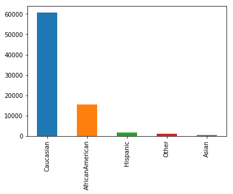

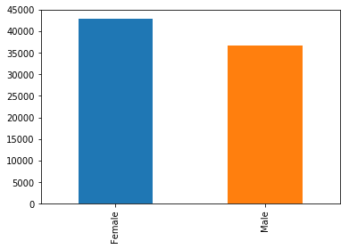

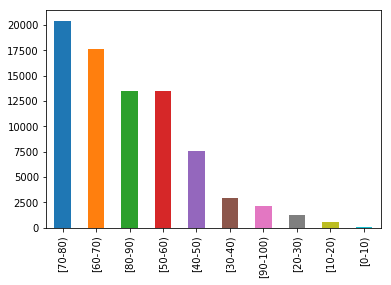

[figure not shown]

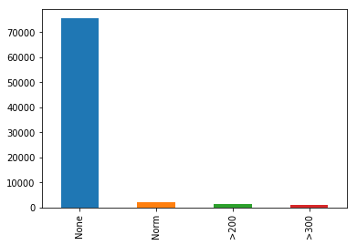

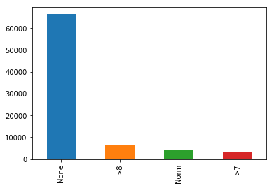

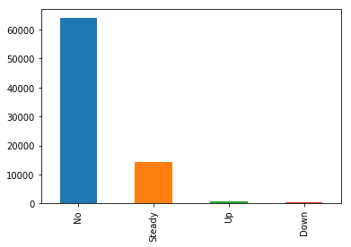

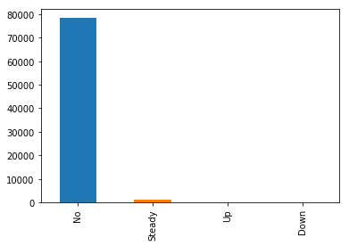

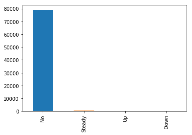

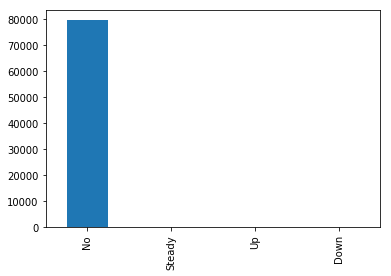

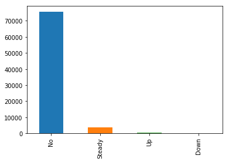

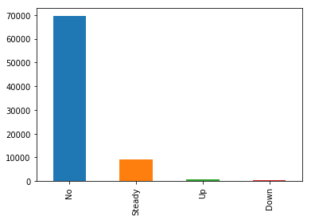

[10 more figures not shown]

```python
for col in categorical:
    categorical[col].value_counts().plot(kind='bar')
    plt.show()
```

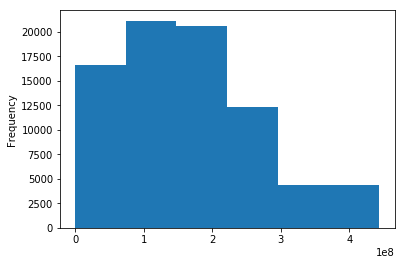

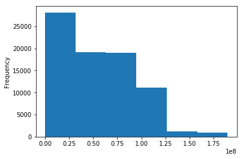

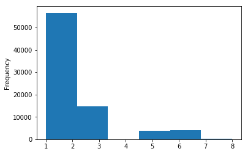

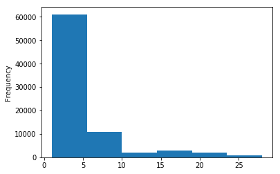

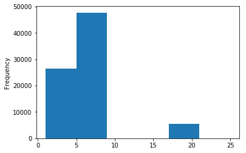

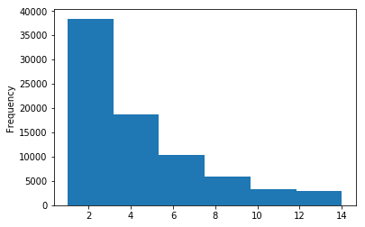

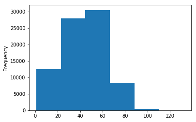

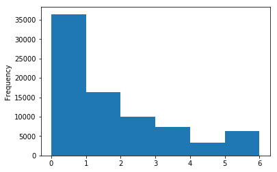

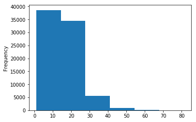

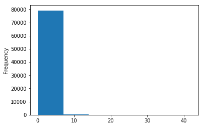

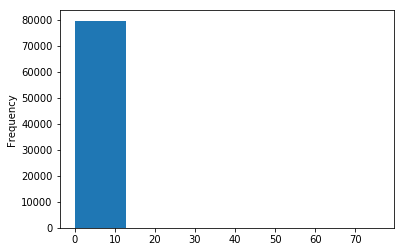

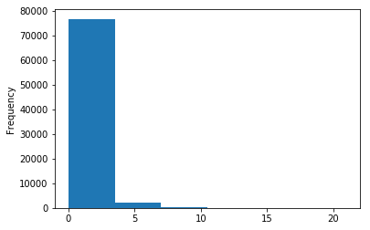

[1 more figures not shown]

```python
for col in numeric:
    numeric[col].plot.hist(bins=6)
    plt.show()
```

```python
# Deleting the 2 columns because they have all the observations only in one category
data.drop(['examide','citoglipton'],axis=1,inplace=True)
data.shape
```

```
(79584, 43)
```

```python
#Making the target variable and other variables binary
data = data[data['readmitted'].isin(['Y', 'N'])]
data['readmitted'] = data['readmitted'].apply(lambda x: 0 if x == "N" else 1)
data['change'] = data['change'].apply(lambda x: 0 if x == "No" else 1)
data['gender'] = data['gender'].apply(lambda x: 0 if x == "Female" else 1)
data['diabetesMed'] = data['diabetesMed'].apply(lambda x: 0 if x == "No" else 1)
data.shape
```

```
(79584, 43)
```

```python
# There are 3 types of visits to a hospital. 1) Inpatient 2) Outpatient 3) Emergency.
# Combining them into a single column
data['total_visits'] = data['number_outpatient'] + data['number_emergency'] + data['number_inpatient']
```

```python
#defining a function to give average value for the age
def agecategory(x):

    if x == "[0-10)" :
        return 5
    elif x == "[10-20)":
        return 15
    elif x == "[20-30)":
        return 25
    elif x == "[30-40)":
        return 35
    elif x == "[40-50)":
        return 45
    elif x == "[50-60)":
        return 55
    elif x == "[60-70)":
        return 65
    elif x == "[70-80)":
        return 75
    else:
        return 0
```

```python
#replacing the age bins with their average value
data['age'] = data['age'].apply(lambda x: agecategory(x))
```

```python
data['age'][:10]
```

```
0     5
1    15
2    25
3    35
4    45
5    55
6    65
7    75
8     0
9    45
Name: age, dtype: int64
```

There are 23 treatments of which 2 treatments are never used by patients and we took the number of treatments the patient has undergone as a feature which will be used for analysis.

```python
#It seems like there are many treatments from which a doctor would recommend the patient, lets combine all the\
#treatments into one dataframe
treatments = ['metformin' ,'repaglinide','nateglinide','chlorpropamide','glimepiride','acetohexamide' ,'glipizide',\
              'glyburide', 'tolbutamide', 'pioglitazone','rosiglitazone', 'acarbose' ,'miglitol' ,'troglitazone', \
              'tolazamide', 'insulin' ,'glyburide-metformin','glipizide-metformin', \
              'glimepiride-pioglitazone', 'metformin-rosiglitazone', 'metformin-pioglitazone']
```

```python
print(treatments)
```

```
['metformin', 'repaglinide', 'nateglinide', 'chlorpropamide', 'glimepiride', 'acetohexamide', 'glipizide', 'glyburide', 'tolbutamide', 'pioglitazone', 'rosiglitazone', 'acarbose', 'miglitol', 'troglitazone', 'tolazamide', 'insulin', 'glyburide-metformin', 'glipizide-metformin', 'glimepiride-pioglita…
```

```python
#assigning a value of 0 if there are not undergoing treatment and assigning 1 even if they are taking \
#increasing/decreasing/steady dosage
for i in treatments:
    data[i] = data[i].apply(lambda x: 0 if x == "No" else 1)
```

```python
#finding out total number of treatments taken by patient
data['treatments_taken'] = np.zeros((len(data['metformin'])))
for col in treatments:
    data['treatments_taken'] += data[col]
```

```python
data.head()
```

|  | encounter_id | patient_nbr | race | gender | age | admission_type_id | discharge_disposition_id | admission_source_id | time_in_hospital | num_lab_procedures | ... | glyburide-metformin | glipizide-metformin | glimepiride-pioglitazone | metformin-rosiglitazone | metformin-pioglitazone | change | diabetesMed | readmitted | total_visits | treatments_taken |
| --- | --- | --- | --- | --- | --- | --- | --- | --- | --- | --- | --- | --- | --- | --- | --- | --- | --- | --- | --- | --- | --- |
| 0 | 2278392 | 8222157 | Caucasian | 0 | 5 | 6 | 25 | 1 | 1 | 41 | ... | 0 | 0 | 0 | 0 | 0 | 0 | 0 | 0 | 0 | 0.0 |
| 1 | 149190 | 55629189 | Caucasian | 0 | 15 | 1 | 1 | 7 | 3 | 59 | ... | 0 | 0 | 0 | 0 | 0 | 1 | 1 | 0 | 0 | 1.0 |
| 2 | 64410 | 86047875 | AfricanAmerican | 0 | 25 | 1 | 1 | 7 | 2 | 11 | ... | 0 | 0 | 0 | 0 | 0 | 0 | 1 | 0 | 3 | 1.0 |
| 3 | 500364 | 82442376 | Caucasian | 1 | 35 | 1 | 1 | 7 | 2 | 44 | ... | 0 | 0 | 0 | 0 | 0 | 1 | 1 | 0 | 0 | 1.0 |
| 4 | 16680 | 42519267 | Caucasian | 1 | 45 | 1 | 1 | 7 | 1 | 51 | ... | 0 | 0 | 0 | 0 | 0 | 1 | 1 | 0 | 0 | 2.0 |

5 rows × 45 columns

```python
# AIC > 6.4 implies that the patient has diabetes. Therefore, considered values greater than 7 and 8 together.
# other 2 categories : Norm and None ; Norm implies the values in the normal range ; None implies no test conducted;
data['A1Cresult'] = data['A1Cresult'].apply(lambda x: 0 if x == "None" else (1 if x=="Norm" else 2) )
data['max_glu_serum'] = data['max_glu_serum'].apply(lambda x: 0 if x == "None" else (1 if x=="Norm" else 2) )
```

```python
#Based on information in https://www.hindawi.com/journals/bmri/2014/781670/tab2/.Classified diagnosis into 9 categories
#Categories[0-8]: Other,Circulatory, Respiratory,Digestive, Diabetes,Injury, Musculoskeletal,Genitourinary,Neoplasms
#defining the function to classify the numbers into one of the 8 categories

def getCategor(x):
    if 'V' in str(x) or 'E' in str(x):
        return 0

    x = float(x)

    if (x >= 390 and x <= 459) or np.floor(x) == 785:
        return 1
    elif (x >= 460 and x <= 519) or np.floor(x) == 786:
        return 2
    elif (x >= 520 and x <= 579) or np.floor(x) == 787:
        return 3
    elif np.floor(x) == 250:
        return 4
    elif x >= 800 and x <= 999:
        return 5
    elif x >= 710 and x <= 739:
        return 6
    elif (x >= 580 and x <= 629) or np.floor(x) == 788:
        return 7
    elif x >= 140 and x <= 239:
        return 8
    else:
        return 0
```

```python
#changing the values into categories
data['diag_1_category'] = data['diag_1'].apply(lambda x: getCategor(x))
```

```python
data['diag_1_category'][:10]
```

```
0    4
1    0
2    0
3    0
4    8
5    1
6    1
7    1
8    1
9    4
Name: diag_1_category, dtype: int64
```

```python
list(data)
```

```
['encounter_id',
 'patient_nbr',
 'race',
 'gender',
 'age',
 'admission_type_id',
 'discharge_disposition_id',
 'admission_source_id',
 'time_in_hospital',
 'num_lab_procedures',
 'num_procedures',
 'num_medications',
 'number_outpatient',
 'number_emergency',
 'number_inpatient',
 'diag_1',
 'number_diagnoses',
 'max_glu_serum',
 'A1Cresult',
 'metformin',
 'repaglinide',
 'nateglinide',
 'chlorpropamide',
 'glimepiride',
 'acetohexamide',
 'glipizide',
 'glyburide',
 'tolbutamide',
 'pioglitazone',
 'rosiglitazone',
 'acarbose',
 'miglitol',
 'troglitazone',
 'tolazamide',
 'insulin',
 'glyburide-metformin',
 'glipizide-metformin',
 'glimepiride-pioglitazone',
 'metformin-rosiglitazone',
 'metformin-pioglitazone',
 'change',
 'diabetesMed',
 'readmitted',
 'total_visits',
 'treatments_taken',
 'diag_1_category']
```

Some patients in the data have more than one encounters, we need to make sure to remove the multiple patient visits because that might cause bias in our predictions. For that reason we remove all the visits by a patient other than their first visit.

```python
#Check for readmitted patients and remove all visits other than the 1st visit
patients = data['patient_nbr']
data[patients.isin(patients[patients.duplicated()])]
```

|  | encounter_id | patient_nbr | race | gender | age | admission_type_id | discharge_disposition_id | admission_source_id | time_in_hospital | num_lab_procedures | ... | glipizide-metformin | glimepiride-pioglitazone | metformin-rosiglitazone | metformin-pioglitazone | change | diabetesMed | readmitted | total_visits | treatments_taken | diag_1_category |
| --- | --- | --- | --- | --- | --- | --- | --- | --- | --- | --- | --- | --- | --- | --- | --- | --- | --- | --- | --- | --- | --- |
| 11 | 40926 | 85504905 | Caucasian | 0 | 45 | 1 | 3 | 7 | 7 | 60 | ... | 0 | 0 | 0 | 0 | 1 | 1 | 1 | 1 | 3.0 | 1 |
| 23 | 250872 | 41606064 | Caucasian | 1 | 25 | 2 | 1 | 2 | 10 | 53 | ... | 0 | 0 | 0 | 0 | 1 | 1 | 0 | 0 | 1.0 | 0 |
| 27 | 293058 | 114715242 | Caucasian | 1 | 65 | 2 | 6 | 2 | 5 | 37 | ... | 0 | 0 | 0 | 0 | 0 | 1 | 0 | 0 | 1.0 | 2 |
| 29 | 325848 | 63023292 | Caucasian | 0 | 65 | 1 | 1 | 7 | 2 | 41 | ... | 0 | 0 | 0 | 0 | 1 | 1 | 0 | 0 | 2.0 | 1 |
| 37 | 486156 | 86240259 | Caucasian | 0 | 75 | 3 | 5 | 4 | 9 | 25 | ... | 0 | 0 | 0 | 0 | 1 | 1 | 1 | 2 | 2.0 | 1 |
| 45 | 676422 | 63754317 | AfricanAmerican | 0 | 75 | 1 | 1 | 7 | 4 | 48 | ... | 0 | 0 | 0 | 0 | 0 | 1 | 0 | 1 | 1.0 | 4 |
| 55 | 881016 | 55152216 | Caucasian | 1 | 55 | 1 | 1 | 7 | 12 | 83 | ... | 0 | 0 | 0 | 0 | 1 | 1 | 0 | 0 | 1.0 | 8 |
| 62 | 1070256 | 23043240 | Caucasian | 0 | 55 | 2 | 1 | 4 | 3 | 41 | ... | 0 | 0 | 0 | 0 | 0 | 1 | 0 | 1 | 1.0 | 1 |
| 64 | 1079592 | 101707335 | Caucasian | 0 | 55 | 1 | 7 | 7 | 5 | 58 | ... | 0 | 0 | 0 | 0 | 1 | 1 | 0 | 2 | 1.0 | 5 |
| 73 | 1195548 | 106343838 | Caucasian | 0 | 75 | 1 | 3 | 7 | 5 | 64 | ... | 0 | 0 | 0 | 0 | 0 | 1 | 0 | 1 | 1.0 | 0 |
| 95 | 2095932 | 276606 | AfricanAmerican | 0 | 35 | 6 | 25 | 7 | 8 | 62 | ... | 0 | 0 | 0 | 0 | 1 | 1 | 0 | 0 | 2.0 | 4 |
| 98 | 2140146 | 53612379 | AfricanAmerican | 0 | 25 | 2 | 1 | 7 | 1 | 56 | ... | 0 | 0 | 0 | 0 | 1 | 1 | 0 | 2 | 1.0 | 4 |
| 110 | 2309376 | 41606064 | Caucasian | 1 | 25 | 2 | 1 | 2 | 2 | 35 | ... | 0 | 0 | 0 | 0 | 0 | 1 | 0 | 1 | 1.0 | 0 |
| 113 | 2356308 | 608841 | AfricanAmerican | 0 | 55 | 6 | 25 | 1 | 1 | 50 | ... | 0 | 0 | 0 | 0 | 0 | 1 | 0 | 0 | 1.0 | 4 |
| 117 | 2429610 | 90460242 | Caucasian | 0 | 55 | 1 | 1 | 7 | 7 | 55 | ... | 0 | 0 | 0 | 0 | 1 | 1 | 0 | 1 | 1.0 | 4 |
| 120 | 2473188 | 981198 | Caucasian | 0 | 65 | 6 | 25 | 1 | 5 | 47 | ... | 0 | 0 | 0 | 0 | 0 | 1 | 0 | 0 | 1.0 | 4 |
| 127 | 2524314 | 384939 | Caucasian | 0 | 45 | 6 | 25 | 7 | 5 | 46 | ... | 0 | 0 | 0 | 0 | 0 | 1 | 0 | 0 | 1.0 | 0 |
| 128 | 2527092 | 708741 | Caucasian | 0 | 0 | 6 | 25 | 7 | 7 | 70 | ... | 0 | 0 | 0 | 0 | 1 | 1 | 0 | 0 | 1.0 | 0 |
| 134 | 2549826 | 688347 | Caucasian | 0 | 55 | 6 | 25 | 7 | 1 | 58 | ... | 0 | 0 | 0 | 0 | 0 | 0 | 0 | 0 | 0.0 | 1 |
| 135 | 2551236 | 1784367 | Caucasian | 1 | 75 | 6 | 25 | 1 | 5 | 39 | ... | 0 | 0 | 0 | 0 | 0 | 0 | 0 | 0 | 0.0 | 0 |
| 136 | 2552952 | 86240259 | Caucasian | 0 | 75 | 1 | 3 | 7 | 11 | 44 | ... | 0 | 0 | 0 | 0 | 1 | 1 | 0 | 7 | 2.0 | 0 |
| 137 | 2553282 | 2604141 | Caucasian | 1 | 0 | 6 | 25 | 7 | 6 | 67 | ... | 0 | 0 | 0 | 0 | 0 | 0 | 0 | 0 | 0.0 | 1 |
| 145 | 2586528 | 1427400 | Caucasian | 0 | 0 | 6 | 25 | 7 | 2 | 48 | ... | 0 | 0 | 0 | 0 | 0 | 0 | 0 | 0 | 0.0 | 4 |
| 151 | 2600796 | 1451637 | Caucasian | 0 | 25 | 6 | 25 | 7 | 1 | 66 | ... | 0 | 0 | 0 | 0 | 0 | 1 | 0 | 0 | 1.0 | 2 |
| 153 | 2629110 | 2283327 | AfricanAmerican | 0 | 45 | 6 | 25 | 1 | 6 | 60 | ... | 0 | 0 | 0 | 0 | 1 | 1 | 1 | 0 | 2.0 | 8 |
| 161 | 2674482 | 2596824 | AfricanAmerican | 1 | 45 | 6 | 25 | 7 | 2 | 52 | ... | 0 | 0 | 0 | 0 | 0 | 1 | 0 | 0 | 1.0 | 2 |
| 164 | 2735352 | 3053970 | AfricanAmerican | 1 | 75 | 6 | 25 | 1 | 1 | 46 | ... | 0 | 0 | 0 | 0 | 1 | 1 | 0 | 0 | 2.0 | 1 |
| 167 | 2738358 | 5014656 | Caucasian | 1 | 65 | 6 | 25 | 7 | 3 | 36 | ... | 0 | 0 | 0 | 0 | 1 | 1 | 0 | 0 | 1.0 | 1 |
| 168 | 2745456 | 634689 | Caucasian | 1 | 55 | 6 | 25 | 7 | 8 | 73 | ... | 0 | 0 | 0 | 0 | 1 | 1 | 1 | 0 | 1.0 | 6 |
| 170 | 2790720 | 48573 | AfricanAmerican | 0 | 0 | 6 | 25 | 1 | 8 | 35 | ... | 0 | 0 | 0 | 0 | 0 | 0 | 1 | 0 | 0.0 | 0 |
| ... | ... | ... | ... | ... | ... | ... | ... | ... | ... | ... | ... | ... | ... | ... | ... | ... | ... | ... | ... | ... | ... |
| 81337 | 442591346 | 108773406 | Caucasian | 1 | 55 | 2 | 1 | 7 | 4 | 40 | ... | 0 | 0 | 0 | 0 | 1 | 1 | 0 | 1 | 3.0 | 0 |
| 81343 | 442641740 | 86023188 | Caucasian | 0 | 0 | 1 | 1 | 7 | 6 | 38 | ... | 0 | 0 | 0 | 0 | 1 | 1 | 0 | 1 | 1.0 | 1 |
| 81344 | 442647692 | 87326991 | Caucasian | 0 | 0 | 1 | 6 | 7 | 2 | 30 | ... | 0 | 0 | 0 | 0 | 1 | 1 | 0 | 4 | 1.0 | 0 |
| 81345 | 442650974 | 88530390 | Caucasian | 0 | 75 | 2 | 1 | 7 | 2 | 1 | ... | 0 | 0 | 0 | 0 | 0 | 1 | 0 | 1 | 1.0 | 1 |
| 81349 | 443102726 | 98403552 | Caucasian | 0 | 0 | 1 | 3 | 7 | 5 | 66 | ... | 0 | 0 | 0 | 0 | 1 | 1 | 0 | 3 | 1.0 | 2 |
| 81351 | 443110856 | 93675141 | AfricanAmerican | 0 | 55 | 1 | 1 | 7 | 4 | 39 | ... | 0 | 0 | 0 | 0 | 1 | 1 | 0 | 0 | 2.0 | 4 |
| 81353 | 443120228 | 86215806 | Caucasian | 0 | 75 | 1 | 4 | 7 | 4 | 9 | ... | 0 | 0 | 0 | 0 | 0 | 1 | 1 | 1 | 1.0 | 0 |
| 81357 | 443139938 | 79902171 | Caucasian | 1 | 0 | 1 | 13 | 7 | 3 | 46 | ... | 0 | 0 | 0 | 0 | 0 | 0 | 0 | 1 | 0.0 | 2 |
| 81358 | 443149022 | 35047287 | Caucasian | 1 | 65 | 2 | 2 | 7 | 4 | 64 | ... | 0 | 0 | 0 | 0 | 1 | 1 | 1 | 0 | 1.0 | 1 |
| 81360 | 443149220 | 106305318 | Caucasian | 0 | 0 | 1 | 3 | 7 | 4 | 44 | ... | 0 | 0 | 0 | 0 | 0 | 0 | 0 | 2 | 0.0 | 7 |
| 81361 | 443163248 | 91310220 | Caucasian | 0 | 0 | 1 | 3 | 7 | 4 | 53 | ... | 0 | 0 | 0 | 0 | 1 | 1 | 0 | 1 | 2.0 | 5 |
| 81362 | 443168882 | 71186301 | Caucasian | 0 | 0 | 1 | 6 | 7 | 4 | 43 | ... | 0 | 0 | 0 | 0 | 1 | 1 | 1 | 3 | 2.0 | 1 |
| 81363 | 443177942 | 110596428 | Caucasian | 0 | 75 | 1 | 3 | 6 | 3 | 39 | ... | 0 | 0 | 0 | 0 | 0 | 1 | 0 | 1 | 1.0 | 1 |
| 81364 | 443185706 | 101236581 | Caucasian | 1 | 0 | 1 | 1 | 7 | 2 | 54 | ... | 0 | 0 | 0 | 0 | 0 | 1 | 0 | 3 | 1.0 | 1 |
| 81366 | 443192642 | 54363114 | Caucasian | 0 | 0 | 1 | 11 | 7 | 4 | 41 | ... | 0 | 0 | 0 | 0 | 1 | 1 | 0 | 1 | 1.0 | 1 |
| 81369 | 443198486 | 29401542 | AfricanAmerican | 1 | 65 | 1 | 1 | 7 | 1 | 28 | ... | 0 | 0 | 0 | 0 | 1 | 1 | 0 | 4 | 2.0 | 2 |
| 81371 | 443207462 | 100677726 | AfricanAmerican | 0 | 0 | 1 | 3 | 7 | 7 | 60 | ... | 0 | 0 | 0 | 0 | 0 | 0 | 0 | 2 | 0.0 | 2 |
| 81372 | 443215478 | 92586510 | Caucasian | 0 | 65 | 1 | 1 | 7 | 5 | 3 | ... | 0 | 0 | 0 | 0 | 1 | 1 | 0 | 2 | 2.0 | 0 |
| 81385 | 443700698 | 69505299 | Caucasian | 0 | 75 | 1 | 1 | 7 | 2 | 33 | ... | 0 | 0 | 0 | 0 | 1 | 1 | 1 | 0 | 1.0 | 3 |
| 81386 | 443710592 | 84391839 | Caucasian | 0 | 35 | 1 | 1 | 7 | 5 | 47 | ... | 0 | 0 | 0 | 0 | 0 | 1 | 0 | 2 | 1.0 | 4 |
| 81391 | 443730002 | 40935762 | Caucasian | 0 | 75 | 1 | 1 | 7 | 6 | 26 | ... | 0 | 0 | 0 | 0 | 0 | 1 | 0 | 5 | 1.0 | 3 |
| 81392 | 443739044 | 106595208 | Caucasian | 1 | 75 | 2 | 6 | 7 | 6 | 46 | ... | 0 | 0 | 0 | 0 | 1 | 1 | 0 | 1 | 1.0 | 3 |
| 81393 | 443739152 | 90751788 | Caucasian | 0 | 65 | 1 | 3 | 7 | 8 | 54 | ... | 0 | 0 | 0 | 0 | 0 | 1 | 0 | 2 | 1.0 | 7 |
| 81397 | 443793992 | 43686936 | Caucasian | 0 | 0 | 1 | 1 | 7 | 1 | 49 | ... | 0 | 0 | 0 | 0 | 0 | 0 | 0 | 0 | 0.0 | 1 |
| 81399 | 443797298 | 89955270 | Caucasian | 1 | 75 | 1 | 1 | 7 | 4 | 2 | ... | 0 | 0 | 0 | 0 | 0 | 1 | 1 | 1 | 1.0 | 1 |
| 81400 | 443804570 | 33230016 | Caucasian | 0 | 75 | 1 | 22 | 7 | 8 | 51 | ... | 0 | 0 | 0 | 0 | 0 | 1 | 0 | 0 | 1.0 | 1 |
| 81407 | 443842136 | 181593374 | Caucasian | 0 | 75 | 1 | 1 | 7 | 5 | 21 | ... | 0 | 0 | 0 | 0 | 0 | 1 | 0 | 1 | 1.0 | 2 |
| 81410 | 443847782 | 74694222 | AfricanAmerican | 0 | 0 | 1 | 4 | 5 | 5 | 33 | ... | 0 | 0 | 0 | 0 | 0 | 1 | 0 | 1 | 1.0 | 3 |
| 81411 | 443854148 | 41088789 | Caucasian | 1 | 75 | 1 | 1 | 7 | 1 | 53 | ... | 0 | 0 | 0 | 0 | 1 | 1 | 0 | 1 | 2.0 | 0 |
| 81412 | 443857166 | 31693671 | Caucasian | 0 | 0 | 2 | 3 | 7 | 10 | 45 | ... | 0 | 0 | 0 | 0 | 1 | 1 | 0 | 1 | 3.0 | 5 |

33490 rows × 46 columns

```python
#dropping the patients encounters other than 1st visit
data = data.drop_duplicates(subset= ['patient_nbr'], keep = 'first')
data.shape
```

```
(58521, 46)
```

Variables like admission_type_id, discharge_despotion_id etc does not have any intrinsic value associated with them. So we make them categorical variables.

```python
# coercing the admission_type_id, discharge_disposition_id, admission_source_id diag_1_category, \
# max_glu_serum, A1Cresult into categorical since the magnitudes does not have any intrinsic value
data['admission_type_id'] = data['admission_type_id'].astype('object')
data['admission_source_id'] = data['admission_source_id'].astype('object')
data['discharge_disposition_id'] = data['discharge_disposition_id'].astype('object')
data['diag_1_category'] = data['diag_1_category'].astype('object')
data['max_glu_serum'] = data['max_glu_serum'].astype('object')
data['A1Cresult'] = data['A1Cresult'].astype('object')
```

Features like encounter_id, patient_nbr are for identity purpose and do not contribute towards predictions, so we get rid of them. Variables like number_outpatient, number_emergency are being used to create new variable which are being used for analysis. So we can get rid of the other variables since we got the target variable which ais going to be used for predictions.

```python
# creating a list for unnecessary columns
delete_columns = ['encounter_id','patient_nbr','number_outpatient','number_emergency','number_inpatient',\
                 'metformin','repaglinide','nateglinide','chlorpropamide','glimepiride','acetohexamide','glipizide'\
                  ,'glyburide','tolbutamide','pioglitazone','rosiglitazone','acarbose','miglitol','troglitazone' \
                  ,'tolazamide','insulin','glyburide-metformin','glipizide-metformin','glimepiride-pioglitazone',\
                  'metformin-rosiglitazone','metformin-pioglitazone','diag_1']
```

```python
#dropping the unnecessary columns
data.drop(delete_columns, inplace=True, axis=1)
```

```python
data.head()
```

|  | race | gender | age | admission_type_id | discharge_disposition_id | admission_source_id | time_in_hospital | num_lab_procedures | num_procedures | num_medications | number_diagnoses | max_glu_serum | A1Cresult | change | diabetesMed | readmitted | total_visits | treatments_taken | diag_1_category |
| --- | --- | --- | --- | --- | --- | --- | --- | --- | --- | --- | --- | --- | --- | --- | --- | --- | --- | --- | --- |
| 0 | Caucasian | 0 | 5 | 6 | 25 | 1 | 1 | 41 | 0 | 1 | 1 | 0 | 0 | 0 | 0 | 0 | 0 | 0.0 | 4 |
| 1 | Caucasian | 0 | 15 | 1 | 1 | 7 | 3 | 59 | 0 | 18 | 9 | 0 | 0 | 1 | 1 | 0 | 0 | 1.0 | 0 |
| 2 | AfricanAmerican | 0 | 25 | 1 | 1 | 7 | 2 | 11 | 5 | 13 | 6 | 0 | 0 | 0 | 1 | 0 | 3 | 1.0 | 0 |
| 3 | Caucasian | 1 | 35 | 1 | 1 | 7 | 2 | 44 | 1 | 16 | 7 | 0 | 0 | 1 | 1 | 0 | 0 | 1.0 | 0 |
| 4 | Caucasian | 1 | 45 | 1 | 1 | 7 | 1 | 51 | 0 | 8 | 5 | 0 | 0 | 1 | 1 | 0 | 0 | 2.0 | 8 |

```python
import numpy as np
from scipy.stats import kurtosis
from scipy.stats import skew
from matplotlib import pyplot as plt
import seaborn as sns
%matplotlib inline
import warnings
warnings.filterwarnings('ignore')
```

```python
#creating a list of categorical and numeric lists
categorical=data.select_dtypes(include=['object'])
numeric=data.select_dtypes(exclude=['object'])
print(categorical.columns.values)
print(numeric.columns.values)
```

```
['race' 'admission_type_id' 'discharge_disposition_id'
 'admission_source_id' 'max_glu_serum' 'A1Cresult' 'diag_1_category']
['gender' 'age' 'time_in_hospital' 'num_lab_procedures' 'num_procedures'
 'num_medications' 'number_diagnoses' 'change' 'diabetesMed' 'readmitted'
 'total_visits' 'treatments_taken']
```

```python
# creating dummies for all the categorical variables and deleting the original columns
nominal_columns = ['race', 'admission_type_id', 'discharge_disposition_id','admission_source_id' ,'diag_1_category'\
                  , 'max_glu_serum', 'A1Cresult']
dummy_df = pd.get_dummies(data[nominal_columns])
data = pd.concat([data, dummy_df], axis=1)
data = data.drop(nominal_columns, axis=1)
```

```python
data.head()
```

|  | gender | age | time_in_hospital | num_lab_procedures | num_procedures | num_medications | number_diagnoses | change | diabetesMed | readmitted | ... | diag_1_category_5 | diag_1_category_6 | diag_1_category_7 | diag_1_category_8 | max_glu_serum_0 | max_glu_serum_1 | max_glu_serum_2 | A1Cresult_0 | A1Cresult_1 | A1Cresult_2 |
| --- | --- | --- | --- | --- | --- | --- | --- | --- | --- | --- | --- | --- | --- | --- | --- | --- | --- | --- | --- | --- | --- |
| 0 | 0 | 5 | 1 | 41 | 0 | 1 | 1 | 0 | 0 | 0 | ... | 0 | 0 | 0 | 0 | 1 | 0 | 0 | 1 | 0 | 0 |
| 1 | 0 | 15 | 3 | 59 | 0 | 18 | 9 | 1 | 1 | 0 | ... | 0 | 0 | 0 | 0 | 1 | 0 | 0 | 1 | 0 | 0 |
| 2 | 0 | 25 | 2 | 11 | 5 | 13 | 6 | 0 | 1 | 0 | ... | 0 | 0 | 0 | 0 | 1 | 0 | 0 | 1 | 0 | 0 |
| 3 | 1 | 35 | 2 | 44 | 1 | 16 | 7 | 1 | 1 | 0 | ... | 0 | 0 | 0 | 0 | 1 | 0 | 0 | 1 | 0 | 0 |
| 4 | 1 | 45 | 1 | 51 | 0 | 8 | 5 | 1 | 1 | 0 | ... | 0 | 0 | 0 | 1 | 1 | 0 | 0 | 1 | 0 | 0 |

5 rows × 83 columns

```python
data1 = data
```

```python
data1
```

|  | gender | age | time_in_hospital | num_lab_procedures | num_procedures | num_medications | number_diagnoses | change | diabetesMed | readmitted | ... | diag_1_category_5 | diag_1_category_6 | diag_1_category_7 | diag_1_category_8 | max_glu_serum_0 | max_glu_serum_1 | max_glu_serum_2 | A1Cresult_0 | A1Cresult_1 | A1Cresult_2 |
| --- | --- | --- | --- | --- | --- | --- | --- | --- | --- | --- | --- | --- | --- | --- | --- | --- | --- | --- | --- | --- | --- |
| 0 | 0 | 5 | 1 | 41 | 0 | 1 | 1 | 0 | 0 | 0 | ... | 0 | 0 | 0 | 0 | 1 | 0 | 0 | 1 | 0 | 0 |
| 1 | 0 | 15 | 3 | 59 | 0 | 18 | 9 | 1 | 1 | 0 | ... | 0 | 0 | 0 | 0 | 1 | 0 | 0 | 1 | 0 | 0 |
| 2 | 0 | 25 | 2 | 11 | 5 | 13 | 6 | 0 | 1 | 0 | ... | 0 | 0 | 0 | 0 | 1 | 0 | 0 | 1 | 0 | 0 |
| 3 | 1 | 35 | 2 | 44 | 1 | 16 | 7 | 1 | 1 | 0 | ... | 0 | 0 | 0 | 0 | 1 | 0 | 0 | 1 | 0 | 0 |
| 4 | 1 | 45 | 1 | 51 | 0 | 8 | 5 | 1 | 1 | 0 | ... | 0 | 0 | 0 | 1 | 1 | 0 | 0 | 1 | 0 | 0 |
| 5 | 1 | 55 | 3 | 31 | 6 | 16 | 9 | 0 | 1 | 0 | ... | 0 | 0 | 0 | 0 | 1 | 0 | 0 | 1 | 0 | 0 |
| 6 | 1 | 65 | 4 | 70 | 1 | 21 | 7 | 1 | 1 | 0 | ... | 0 | 0 | 0 | 0 | 1 | 0 | 0 | 1 | 0 | 0 |
| 7 | 1 | 75 | 5 | 73 | 0 | 12 | 8 | 0 | 1 | 0 | ... | 0 | 0 | 0 | 0 | 1 | 0 | 0 | 1 | 0 | 0 |
| 8 | 0 | 0 | 13 | 68 | 2 | 28 | 8 | 1 | 1 | 0 | ... | 0 | 0 | 0 | 0 | 1 | 0 | 0 | 1 | 0 | 0 |
| 9 | 0 | 45 | 9 | 47 | 2 | 17 | 9 | 0 | 1 | 0 | ... | 0 | 0 | 0 | 0 | 1 | 0 | 0 | 1 | 0 | 0 |
| 10 | 1 | 65 | 7 | 62 | 0 | 11 | 7 | 1 | 1 | 1 | ... | 0 | 0 | 0 | 1 | 1 | 0 | 0 | 1 | 0 | 0 |
| 11 | 0 | 45 | 7 | 60 | 0 | 15 | 8 | 1 | 1 | 1 | ... | 0 | 0 | 0 | 0 | 1 | 0 | 0 | 1 | 0 | 0 |
| 12 | 1 | 0 | 10 | 55 | 1 | 31 | 8 | 0 | 1 | 0 | ... | 0 | 0 | 0 | 0 | 1 | 0 | 0 | 1 | 0 | 0 |
| 13 | 1 | 65 | 12 | 75 | 5 | 13 | 9 | 1 | 1 | 0 | ... | 1 | 0 | 0 | 0 | 1 | 0 | 0 | 1 | 0 | 0 |
| 14 | 1 | 55 | 4 | 45 | 4 | 17 | 8 | 1 | 1 | 1 | ... | 0 | 0 | 0 | 0 | 1 | 0 | 0 | 1 | 0 | 0 |
| 15 | 0 | 55 | 3 | 29 | 0 | 11 | 3 | 0 | 1 | 0 | ... | 0 | 0 | 0 | 0 | 1 | 0 | 0 | 1 | 0 | 0 |
| 16 | 1 | 75 | 5 | 35 | 5 | 23 | 9 | 0 | 1 | 0 | ... | 0 | 0 | 0 | 0 | 1 | 0 | 0 | 1 | 0 | 0 |
| 19 | 0 | 75 | 2 | 47 | 0 | 12 | 8 | 0 | 0 | 0 | ... | 0 | 0 | 0 | 0 | 1 | 0 | 0 | 1 | 0 | 0 |
| 20 | 0 | 75 | 3 | 19 | 4 | 18 | 6 | 1 | 1 | 0 | ... | 0 | 0 | 0 | 1 | 1 | 0 | 0 | 1 | 0 | 0 |
| 21 | 0 | 55 | 1 | 33 | 0 | 7 | 3 | 0 | 1 | 0 | ... | 0 | 0 | 0 | 0 | 1 | 0 | 0 | 1 | 0 | 0 |
| 22 | 1 | 0 | 6 | 64 | 3 | 18 | 7 | 1 | 1 | 0 | ... | 0 | 0 | 0 | 0 | 1 | 0 | 0 | 0 | 0 | 1 |
| 23 | 1 | 25 | 10 | 53 | 0 | 20 | 6 | 1 | 1 | 0 | ... | 0 | 0 | 0 | 0 | 1 | 0 | 0 | 1 | 0 | 0 |
| 24 | 0 | 0 | 5 | 52 | 0 | 14 | 8 | 1 | 1 | 0 | ... | 0 | 0 | 0 | 0 | 1 | 0 | 0 | 1 | 0 | 0 |
| 25 | 0 | 65 | 6 | 87 | 0 | 18 | 9 | 1 | 1 | 0 | ... | 0 | 0 | 1 | 0 | 1 | 0 | 0 | 1 | 0 | 0 |
| 26 | 1 | 75 | 1 | 53 | 0 | 10 | 8 | 1 | 1 | 0 | ... | 0 | 0 | 0 | 0 | 1 | 0 | 0 | 1 | 0 | 0 |
| 27 | 1 | 65 | 5 | 37 | 0 | 18 | 8 | 0 | 1 | 0 | ... | 0 | 0 | 0 | 0 | 1 | 0 | 0 | 1 | 0 | 0 |
| 28 | 0 | 75 | 5 | 46 | 2 | 20 | 9 | 1 | 1 | 0 | ... | 0 | 0 | 0 | 0 | 1 | 0 | 0 | 1 | 0 | 0 |
| 29 | 0 | 65 | 2 | 41 | 0 | 11 | 6 | 1 | 1 | 0 | ... | 0 | 0 | 0 | 0 | 1 | 0 | 0 | 1 | 0 | 0 |
| 30 | 0 | 65 | 4 | 33 | 0 | 12 | 3 | 1 | 1 | 0 | ... | 0 | 0 | 0 | 0 | 1 | 0 | 0 | 1 | 0 | 0 |
| 31 | 1 | 75 | 7 | 47 | 2 | 22 | 8 | 1 | 1 | 0 | ... | 1 | 0 | 0 | 0 | 1 | 0 | 0 | 1 | 0 | 0 |
| ... | ... | ... | ... | ... | ... | ... | ... | ... | ... | ... | ... | ... | ... | ... | ... | ... | ... | ... | ... | ... | ... |
| 81368 | 1 | 55 | 5 | 39 | 2 | 28 | 7 | 1 | 1 | 0 | ... | 1 | 0 | 0 | 0 | 1 | 0 | 0 | 1 | 0 | 0 |
| 81370 | 0 | 35 | 3 | 30 | 1 | 10 | 9 | 1 | 1 | 0 | ... | 0 | 0 | 0 | 0 | 1 | 0 | 0 | 1 | 0 | 0 |
| 81373 | 1 | 45 | 3 | 62 | 0 | 14 | 8 | 1 | 1 | 0 | ... | 0 | 0 | 0 | 0 | 1 | 0 | 0 | 0 | 0 | 1 |
| 81374 | 0 | 75 | 1 | 1 | 0 | 5 | 9 | 0 | 1 | 0 | ... | 0 | 0 | 0 | 0 | 1 | 0 | 0 | 0 | 0 | 1 |
| 81375 | 1 | 75 | 8 | 67 | 3 | 35 | 9 | 1 | 1 | 0 | ... | 0 | 0 | 0 | 0 | 1 | 0 | 0 | 1 | 0 | 0 |
| 81376 | 1 | 55 | 9 | 81 | 6 | 28 | 9 | 0 | 1 | 0 | ... | 0 | 0 | 0 | 0 | 1 | 0 | 0 | 0 | 1 | 0 |
| 81377 | 0 | 75 | 2 | 48 | 0 | 18 | 9 | 0 | 1 | 0 | ... | 0 | 0 | 0 | 0 | 1 | 0 | 0 | 1 | 0 | 0 |
| 81378 | 1 | 15 | 1 | 59 | 6 | 9 | 1 | 1 | 1 | 0 | ... | 0 | 0 | 0 | 0 | 1 | 0 | 0 | 1 | 0 | 0 |
| 81379 | 1 | 55 | 5 | 71 | 5 | 23 | 9 | 1 | 1 | 0 | ... | 0 | 0 | 1 | 0 | 1 | 0 | 0 | 0 | 0 | 1 |
| 81380 | 0 | 75 | 6 | 40 | 1 | 18 | 9 | 1 | 1 | 0 | ... | 0 | 0 | 1 | 0 | 1 | 0 | 0 | 1 | 0 | 0 |
| 81381 | 1 | 65 | 3 | 41 | 1 | 13 | 7 | 0 | 1 | 0 | ... | 0 | 1 | 0 | 0 | 1 | 0 | 0 | 1 | 0 | 0 |
| 81382 | 1 | 65 | 7 | 91 | 4 | 23 | 9 | 0 | 1 | 0 | ... | 0 | 0 | 0 | 0 | 1 | 0 | 0 | 1 | 0 | 0 |
| 81383 | 0 | 75 | 12 | 72 | 6 | 26 | 9 | 1 | 1 | 0 | ... | 0 | 0 | 0 | 0 | 1 | 0 | 0 | 1 | 0 | 0 |
| 81384 | 1 | 35 | 5 | 1 | 1 | 23 | 7 | 1 | 1 | 0 | ... | 0 | 0 | 0 | 0 | 1 | 0 | 0 | 1 | 0 | 0 |
| 81387 | 0 | 75 | 4 | 35 | 0 | 14 | 9 | 0 | 1 | 0 | ... | 0 | 0 | 0 | 0 | 1 | 0 | 0 | 1 | 0 | 0 |
| 81388 | 0 | 75 | 3 | 57 | 4 | 11 | 9 | 0 | 0 | 0 | ... | 0 | 0 | 0 | 0 | 1 | 0 | 0 | 1 | 0 | 0 |
| 81390 | 0 | 0 | 6 | 51 | 0 | 17 | 9 | 1 | 1 | 0 | ... | 0 | 0 | 0 | 0 | 1 | 0 | 0 | 1 | 0 | 0 |
| 81394 | 0 | 45 | 4 | 50 | 4 | 25 | 9 | 1 | 1 | 0 | ... | 0 | 0 | 0 | 1 | 1 | 0 | 0 | 1 | 0 | 0 |
| 81395 | 1 | 45 | 1 | 1 | 5 | 8 | 4 | 1 | 1 | 0 | ... | 0 | 0 | 0 | 0 | 1 | 0 | 0 | 1 | 0 | 0 |
| 81396 | 1 | 0 | 3 | 45 | 0 | 26 | 9 | 1 | 1 | 0 | ... | 0 | 0 | 0 | 0 | 1 | 0 | 0 | 1 | 0 | 0 |
| 81398 | 1 | 55 | 3 | 57 | 0 | 7 | 3 | 1 | 1 | 0 | ... | 0 | 0 | 0 | 0 | 1 | 0 | 0 | 0 | 0 | 1 |
| 81401 | 0 | 45 | 14 | 69 | 0 | 16 | 5 | 1 | 1 | 0 | ... | 0 | 0 | 0 | 0 | 1 | 0 | 0 | 0 | 0 | 1 |
| 81402 | 0 | 0 | 3 | 31 | 2 | 24 | 9 | 1 | 1 | 1 | ... | 0 | 0 | 0 | 0 | 1 | 0 | 0 | 1 | 0 | 0 |
| 81403 | 1 | 75 | 13 | 77 | 6 | 65 | 16 | 1 | 1 | 0 | ... | 0 | 0 | 0 | 0 | 1 | 0 | 0 | 0 | 1 | 0 |
| 81404 | 0 | 45 | 3 | 13 | 1 | 5 | 8 | 1 | 1 | 0 | ... | 0 | 0 | 0 | 0 | 1 | 0 | 0 | 1 | 0 | 0 |
| 81405 | 0 | 45 | 14 | 73 | 6 | 26 | 9 | 1 | 1 | 0 | ... | 0 | 0 | 1 | 0 | 1 | 0 | 0 | 0 | 0 | 1 |
| 81406 | 0 | 65 | 2 | 46 | 6 | 17 | 9 | 0 | 1 | 0 | ... | 1 | 0 | 0 | 0 | 1 | 0 | 0 | 1 | 0 | 0 |
| 81408 | 0 | 0 | 5 | 76 | 1 | 22 | 9 | 1 | 1 | 0 | ... | 0 | 0 | 0 | 0 | 1 | 0 | 0 | 1 | 0 | 0 |
| 81409 | 1 | 75 | 3 | 51 | 0 | 16 | 9 | 1 | 1 | 0 | ... | 0 | 0 | 0 | 0 | 1 | 0 | 0 | 0 | 0 | 1 |
| 81413 | 1 | 75 | 6 | 13 | 3 | 3 | 9 | 0 | 0 | 0 | ... | 0 | 0 | 0 | 0 | 1 | 0 | 0 | 1 | 0 | 0 |

58521 rows × 83 columns

```python
y = data1['readmitted']
```

```python
X = data1.drop('readmitted',axis=1)
```

```python
X_train, X_test, Y_train, Y_test = train_test_split(X,y, test_size=0.20, random_state=42)
```

```python
from sklearn.ensemble import RandomForestClassifier
from sklearn.feature_selection import SelectFromModel
from sklearn.model_selection import GridSearchCV
clf = RandomForestClassifier(n_estimators=64, max_features='sqrt')
clf = clf.fit(X_train, Y_train)
```

```python
features = pd.DataFrame()
features['feature'] = X_train.columns
features['importance'] = clf.feature_importances_
features.sort_values(by=['importance'], ascending=True, inplace=True)
features.set_index('feature', inplace=True)
```

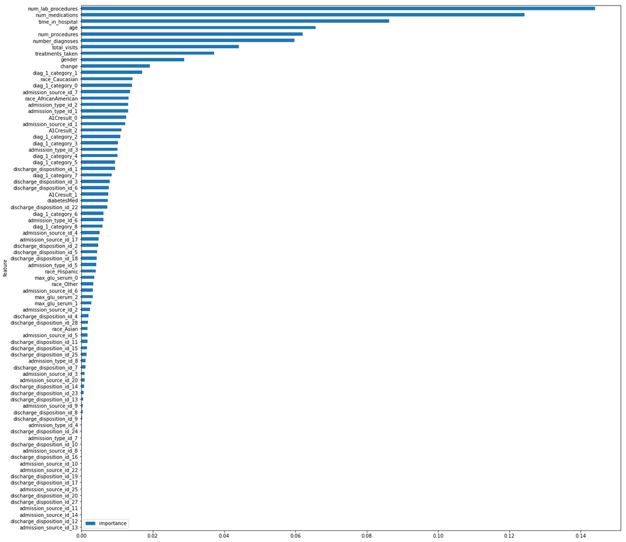

```python
features.plot(kind='barh', figsize=(20, 20))
```

```python
#deleting all the low important features starting from diag_1_category_8
low_importance_features = ['diag_1_category_8','admission_source_id_4', 'discharge_disposition_id_2','admission_source_id_17',\
      'discharge_disposition_id_18','admission_type_id_5','discharge_disposition_id_5','race_Hispanic',\
      'max_glu_serum_0', 'max_glu_serum_2', 'race_Other', 'admission_source_id_6','max_glu_serum_1',\
      'admission_source_id_2','discharge_disposition_id_4','admission_source_id_5', 'race_Asian', \
      'discharge_disposition_id_28','discharge_disposition_id_11','discharge_disposition_id_15',\
      'discharge_disposition_id_25','discharge_disposition_id_7', 'admission_type_id_8', 'admission_source_id_3',\
      'admission_source_id_20','discharge_disposition_id_23','discharge_disposition_id_14','discharge_disposition_id_13',\
      'discharge_disposition_id_8','discharge_disposition_id_16', 'admission_source_id_9', 'discharge_disposition_id_9','discharge_disposition_id_24',\
      'admission_type_id_4','admission_type_id_7','admission_source_id_10','discharge_disposition_id_19','discharge_disposition_id_17',\
      'admission_source_id_8','discharge_disposition_id_16','admission_source_id_25','discharge_disposition_id_10','discharge_disposition_id_20',\
      'admission_source_id_13','admission_source_id_11','admission_source_id_22','admission_source_id_14',\
      'discharge_disposition_id_27','discharge_disposition_id_12']
```

```python
data_final = data1.drop(low_importance_features, axis = 1)
```

```python
data_final
```

|  | gender | age | time_in_hospital | num_lab_procedures | num_procedures | num_medications | number_diagnoses | change | diabetesMed | readmitted | ... | diag_1_category_1 | diag_1_category_2 | diag_1_category_3 | diag_1_category_4 | diag_1_category_5 | diag_1_category_6 | diag_1_category_7 | A1Cresult_0 | A1Cresult_1 | A1Cresult_2 |
| --- | --- | --- | --- | --- | --- | --- | --- | --- | --- | --- | --- | --- | --- | --- | --- | --- | --- | --- | --- | --- | --- |
| 0 | 0 | 5 | 1 | 41 | 0 | 1 | 1 | 0 | 0 | 0 | ... | 0 | 0 | 0 | 1 | 0 | 0 | 0 | 1 | 0 | 0 |
| 1 | 0 | 15 | 3 | 59 | 0 | 18 | 9 | 1 | 1 | 0 | ... | 0 | 0 | 0 | 0 | 0 | 0 | 0 | 1 | 0 | 0 |
| 2 | 0 | 25 | 2 | 11 | 5 | 13 | 6 | 0 | 1 | 0 | ... | 0 | 0 | 0 | 0 | 0 | 0 | 0 | 1 | 0 | 0 |
| 3 | 1 | 35 | 2 | 44 | 1 | 16 | 7 | 1 | 1 | 0 | ... | 0 | 0 | 0 | 0 | 0 | 0 | 0 | 1 | 0 | 0 |
| 4 | 1 | 45 | 1 | 51 | 0 | 8 | 5 | 1 | 1 | 0 | ... | 0 | 0 | 0 | 0 | 0 | 0 | 0 | 1 | 0 | 0 |
| 5 | 1 | 55 | 3 | 31 | 6 | 16 | 9 | 0 | 1 | 0 | ... | 1 | 0 | 0 | 0 | 0 | 0 | 0 | 1 | 0 | 0 |
| 6 | 1 | 65 | 4 | 70 | 1 | 21 | 7 | 1 | 1 | 0 | ... | 1 | 0 | 0 | 0 | 0 | 0 | 0 | 1 | 0 | 0 |
| 7 | 1 | 75 | 5 | 73 | 0 | 12 | 8 | 0 | 1 | 0 | ... | 1 | 0 | 0 | 0 | 0 | 0 | 0 | 1 | 0 | 0 |
| 8 | 0 | 0 | 13 | 68 | 2 | 28 | 8 | 1 | 1 | 0 | ... | 1 | 0 | 0 | 0 | 0 | 0 | 0 | 1 | 0 | 0 |
| 9 | 0 | 45 | 9 | 47 | 2 | 17 | 9 | 0 | 1 | 0 | ... | 0 | 0 | 0 | 1 | 0 | 0 | 0 | 1 | 0 | 0 |
| 10 | 1 | 65 | 7 | 62 | 0 | 11 | 7 | 1 | 1 | 1 | ... | 0 | 0 | 0 | 0 | 0 | 0 | 0 | 1 | 0 | 0 |
| 11 | 0 | 45 | 7 | 60 | 0 | 15 | 8 | 1 | 1 | 1 | ... | 1 | 0 | 0 | 0 | 0 | 0 | 0 | 1 | 0 | 0 |
| 12 | 1 | 0 | 10 | 55 | 1 | 31 | 8 | 0 | 1 | 0 | ... | 1 | 0 | 0 | 0 | 0 | 0 | 0 | 1 | 0 | 0 |
| 13 | 1 | 65 | 12 | 75 | 5 | 13 | 9 | 1 | 1 | 0 | ... | 0 | 0 | 0 | 0 | 1 | 0 | 0 | 1 | 0 | 0 |
| 14 | 1 | 55 | 4 | 45 | 4 | 17 | 8 | 1 | 1 | 1 | ... | 1 | 0 | 0 | 0 | 0 | 0 | 0 | 1 | 0 | 0 |
| 15 | 0 | 55 | 3 | 29 | 0 | 11 | 3 | 0 | 1 | 0 | ... | 0 | 0 | 0 | 0 | 0 | 0 | 0 | 1 | 0 | 0 |
| 16 | 1 | 75 | 5 | 35 | 5 | 23 | 9 | 0 | 1 | 0 | ... | 1 | 0 | 0 | 0 | 0 | 0 | 0 | 1 | 0 | 0 |
| 19 | 0 | 75 | 2 | 47 | 0 | 12 | 8 | 0 | 0 | 0 | ... | 1 | 0 | 0 | 0 | 0 | 0 | 0 | 1 | 0 | 0 |
| 20 | 0 | 75 | 3 | 19 | 4 | 18 | 6 | 1 | 1 | 0 | ... | 0 | 0 | 0 | 0 | 0 | 0 | 0 | 1 | 0 | 0 |
| 21 | 0 | 55 | 1 | 33 | 0 | 7 | 3 | 0 | 1 | 0 | ... | 0 | 1 | 0 | 0 | 0 | 0 | 0 | 1 | 0 | 0 |
| 22 | 1 | 0 | 6 | 64 | 3 | 18 | 7 | 1 | 1 | 0 | ... | 1 | 0 | 0 | 0 | 0 | 0 | 0 | 0 | 0 | 1 |
| 23 | 1 | 25 | 10 | 53 | 0 | 20 | 6 | 1 | 1 | 0 | ... | 0 | 0 | 0 | 0 | 0 | 0 | 0 | 1 | 0 | 0 |
| 24 | 0 | 0 | 5 | 52 | 0 | 14 | 8 | 1 | 1 | 0 | ... | 1 | 0 | 0 | 0 | 0 | 0 | 0 | 1 | 0 | 0 |
| 25 | 0 | 65 | 6 | 87 | 0 | 18 | 9 | 1 | 1 | 0 | ... | 0 | 0 | 0 | 0 | 0 | 0 | 1 | 1 | 0 | 0 |
| 26 | 1 | 75 | 1 | 53 | 0 | 10 | 8 | 1 | 1 | 0 | ... | 0 | 1 | 0 | 0 | 0 | 0 | 0 | 1 | 0 | 0 |
| 27 | 1 | 65 | 5 | 37 | 0 | 18 | 8 | 0 | 1 | 0 | ... | 0 | 1 | 0 | 0 | 0 | 0 | 0 | 1 | 0 | 0 |
| 28 | 0 | 75 | 5 | 46 | 2 | 20 | 9 | 1 | 1 | 0 | ... | 1 | 0 | 0 | 0 | 0 | 0 | 0 | 1 | 0 | 0 |
| 29 | 0 | 65 | 2 | 41 | 0 | 11 | 6 | 1 | 1 | 0 | ... | 1 | 0 | 0 | 0 | 0 | 0 | 0 | 1 | 0 | 0 |
| 30 | 0 | 65 | 4 | 33 | 0 | 12 | 3 | 1 | 1 | 0 | ... | 0 | 1 | 0 | 0 | 0 | 0 | 0 | 1 | 0 | 0 |
| 31 | 1 | 75 | 7 | 47 | 2 | 22 | 8 | 1 | 1 | 0 | ... | 0 | 0 | 0 | 0 | 1 | 0 | 0 | 1 | 0 | 0 |
| ... | ... | ... | ... | ... | ... | ... | ... | ... | ... | ... | ... | ... | ... | ... | ... | ... | ... | ... | ... | ... | ... |
| 81368 | 1 | 55 | 5 | 39 | 2 | 28 | 7 | 1 | 1 | 0 | ... | 0 | 0 | 0 | 0 | 1 | 0 | 0 | 1 | 0 | 0 |
| 81370 | 0 | 35 | 3 | 30 | 1 | 10 | 9 | 1 | 1 | 0 | ... | 0 | 0 | 0 | 0 | 0 | 0 | 0 | 1 | 0 | 0 |
| 81373 | 1 | 45 | 3 | 62 | 0 | 14 | 8 | 1 | 1 | 0 | ... | 0 | 0 | 0 | 1 | 0 | 0 | 0 | 0 | 0 | 1 |
| 81374 | 0 | 75 | 1 | 1 | 0 | 5 | 9 | 0 | 1 | 0 | ... | 0 | 1 | 0 | 0 | 0 | 0 | 0 | 0 | 0 | 1 |
| 81375 | 1 | 75 | 8 | 67 | 3 | 35 | 9 | 1 | 1 | 0 | ... | 0 | 0 | 1 | 0 | 0 | 0 | 0 | 1 | 0 | 0 |
| 81376 | 1 | 55 | 9 | 81 | 6 | 28 | 9 | 0 | 1 | 0 | ... | 0 | 1 | 0 | 0 | 0 | 0 | 0 | 0 | 1 | 0 |
| 81377 | 0 | 75 | 2 | 48 | 0 | 18 | 9 | 0 | 1 | 0 | ... | 1 | 0 | 0 | 0 | 0 | 0 | 0 | 1 | 0 | 0 |
| 81378 | 1 | 15 | 1 | 59 | 6 | 9 | 1 | 1 | 1 | 0 | ... | 0 | 0 | 0 | 1 | 0 | 0 | 0 | 1 | 0 | 0 |
| 81379 | 1 | 55 | 5 | 71 | 5 | 23 | 9 | 1 | 1 | 0 | ... | 0 | 0 | 0 | 0 | 0 | 0 | 1 | 0 | 0 | 1 |
| 81380 | 0 | 75 | 6 | 40 | 1 | 18 | 9 | 1 | 1 | 0 | ... | 0 | 0 | 0 | 0 | 0 | 0 | 1 | 1 | 0 | 0 |
| 81381 | 1 | 65 | 3 | 41 | 1 | 13 | 7 | 0 | 1 | 0 | ... | 0 | 0 | 0 | 0 | 0 | 1 | 0 | 1 | 0 | 0 |
| 81382 | 1 | 65 | 7 | 91 | 4 | 23 | 9 | 0 | 1 | 0 | ... | 0 | 1 | 0 | 0 | 0 | 0 | 0 | 1 | 0 | 0 |
| 81383 | 0 | 75 | 12 | 72 | 6 | 26 | 9 | 1 | 1 | 0 | ... | 1 | 0 | 0 | 0 | 0 | 0 | 0 | 1 | 0 | 0 |
| 81384 | 1 | 35 | 5 | 1 | 1 | 23 | 7 | 1 | 1 | 0 | ... | 0 | 0 | 0 | 0 | 0 | 0 | 0 | 1 | 0 | 0 |
| 81387 | 0 | 75 | 4 | 35 | 0 | 14 | 9 | 0 | 1 | 0 | ... | 0 | 0 | 0 | 0 | 0 | 0 | 0 | 1 | 0 | 0 |
| 81388 | 0 | 75 | 3 | 57 | 4 | 11 | 9 | 0 | 0 | 0 | ... | 0 | 1 | 0 | 0 | 0 | 0 | 0 | 1 | 0 | 0 |
| 81390 | 0 | 0 | 6 | 51 | 0 | 17 | 9 | 1 | 1 | 0 | ... | 0 | 1 | 0 | 0 | 0 | 0 | 0 | 1 | 0 | 0 |
| 81394 | 0 | 45 | 4 | 50 | 4 | 25 | 9 | 1 | 1 | 0 | ... | 0 | 0 | 0 | 0 | 0 | 0 | 0 | 1 | 0 | 0 |
| 81395 | 1 | 45 | 1 | 1 | 5 | 8 | 4 | 1 | 1 | 0 | ... | 1 | 0 | 0 | 0 | 0 | 0 | 0 | 1 | 0 | 0 |
| 81396 | 1 | 0 | 3 | 45 | 0 | 26 | 9 | 1 | 1 | 0 | ... | 0 | 1 | 0 | 0 | 0 | 0 | 0 | 1 | 0 | 0 |
| 81398 | 1 | 55 | 3 | 57 | 0 | 7 | 3 | 1 | 1 | 0 | ... | 0 | 0 | 0 | 0 | 0 | 0 | 0 | 0 | 0 | 1 |
| 81401 | 0 | 45 | 14 | 69 | 0 | 16 | 5 | 1 | 1 | 0 | ... | 0 | 0 | 0 | 0 | 0 | 0 | 0 | 0 | 0 | 1 |
| 81402 | 0 | 0 | 3 | 31 | 2 | 24 | 9 | 1 | 1 | 1 | ... | 0 | 0 | 1 | 0 | 0 | 0 | 0 | 1 | 0 | 0 |
| 81403 | 1 | 75 | 13 | 77 | 6 | 65 | 16 | 1 | 1 | 0 | ... | 1 | 0 | 0 | 0 | 0 | 0 | 0 | 0 | 1 | 0 |
| 81404 | 0 | 45 | 3 | 13 | 1 | 5 | 8 | 1 | 1 | 0 | ... | 0 | 0 | 0 | 0 | 0 | 0 | 0 | 1 | 0 | 0 |
| 81405 | 0 | 45 | 14 | 73 | 6 | 26 | 9 | 1 | 1 | 0 | ... | 0 | 0 | 0 | 0 | 0 | 0 | 1 | 0 | 0 | 1 |
| 81406 | 0 | 65 | 2 | 46 | 6 | 17 | 9 | 0 | 1 | 0 | ... | 0 | 0 | 0 | 0 | 1 | 0 | 0 | 1 | 0 | 0 |
| 81408 | 0 | 0 | 5 | 76 | 1 | 22 | 9 | 1 | 1 | 0 | ... | 0 | 0 | 0 | 0 | 0 | 0 | 0 | 1 | 0 | 0 |
| 81409 | 1 | 75 | 3 | 51 | 0 | 16 | 9 | 1 | 1 | 0 | ... | 0 | 0 | 0 | 1 | 0 | 0 | 0 | 0 | 0 | 1 |
| 81413 | 1 | 75 | 6 | 13 | 3 | 3 | 9 | 0 | 0 | 0 | ... | 0 | 0 | 1 | 0 | 0 | 0 | 0 | 1 | 0 | 0 |

58521 rows × 35 columns

```python
#removing the low_importance columns and creating a new dataframe
```

```python
y = data_final['readmitted']
```

```python
X = data_final.drop('readmitted',axis=1)
```

```python
X_train, X_test, Y_train, Y_test = train_test_split(X,y, test_size=0.20, random_state=42)
```

# Decision Tree

```python
from sklearn.tree import DecisionTreeClassifier
from sklearn.metrics import classification_report, f1_score, accuracy_score, precision_score, recall_score
```

```python
from sklearn.model_selection import cross_val_score

performance = []
for max_depth in [2,3,5,7,10]:
    dTree = DecisionTreeClassifier(criterion='entropy', class_weight = "balanced", max_depth=max_depth)
    performance.append((max_depth, np.mean(cross_val_score(dTree, X_train, Y_train, cv = 10, scoring = "f1_micro"))))
```

```python
print(performance)
print("The best tree size is: ")
str(sorted(performance, key = lambda x: x[1])[-1][0])
```

```
[(2, 0.4805196801561129), (3, 0.5048704164663225), (5, 0.5437684958169761), (7, 0.5630766435537302), (10, 0.5823860232422763)]
The best tree size is:
```

```
'10'
```

```python
X_train
```

|  | gender | age | time_in_hospital | num_lab_procedures | num_procedures | num_medications | number_diagnoses | change | diabetesMed | total_visits | ... | diag_1_category_1 | diag_1_category_2 | diag_1_category_3 | diag_1_category_4 | diag_1_category_5 | diag_1_category_6 | diag_1_category_7 | A1Cresult_0 | A1Cresult_1 | A1Cresult_2 |
| --- | --- | --- | --- | --- | --- | --- | --- | --- | --- | --- | --- | --- | --- | --- | --- | --- | --- | --- | --- | --- | --- |
| 22990 | 1 | 75 | 3 | 55 | 1 | 19 | 6 | 0 | 0 | 3 | ... | 0 | 0 | 0 | 0 | 0 | 0 | 0 | 1 | 0 | 0 |
| 40949 | 1 | 75 | 8 | 44 | 6 | 24 | 9 | 1 | 1 | 2 | ... | 0 | 0 | 1 | 0 | 0 | 0 | 0 | 1 | 0 | 0 |
| 66248 | 1 | 65 | 4 | 68 | 2 | 13 | 9 | 0 | 0 | 0 | ... | 1 | 0 | 0 | 0 | 0 | 0 | 0 | 0 | 0 | 1 |
| 12757 | 1 | 0 | 8 | 2 | 2 | 10 | 8 | 0 | 1 | 4 | ... | 1 | 0 | 0 | 0 | 0 | 0 | 0 | 1 | 0 | 0 |
| 48624 | 0 | 65 | 5 | 54 | 0 | 24 | 8 | 1 | 1 | 1 | ... | 0 | 1 | 0 | 0 | 0 | 0 | 0 | 1 | 0 | 0 |
| 40773 | 0 | 55 | 1 | 3 | 2 | 13 | 4 | 0 | 0 | 0 | ... | 0 | 0 | 0 | 0 | 0 | 1 | 0 | 1 | 0 | 0 |
| 18202 | 0 | 65 | 2 | 62 | 0 | 13 | 9 | 0 | 1 | 0 | ... | 1 | 0 | 0 | 0 | 0 | 0 | 0 | 1 | 0 | 0 |
| 1603 | 0 | 45 | 4 | 56 | 0 | 10 | 4 | 1 | 1 | 2 | ... | 0 | 0 | 0 | 1 | 0 | 0 | 0 | 0 | 0 | 1 |
| 54923 | 0 | 65 | 2 | 45 | 4 | 15 | 8 | 0 | 0 | 0 | ... | 1 | 0 | 0 | 0 | 0 | 0 | 0 | 0 | 0 | 1 |
| 21521 | 1 | 65 | 7 | 70 | 3 | 12 | 9 | 0 | 0 | 0 | ... | 0 | 0 | 0 | 0 | 0 | 0 | 0 | 1 | 0 | 0 |
| 70324 | 1 | 55 | 3 | 26 | 1 | 22 | 9 | 1 | 1 | 0 | ... | 0 | 0 | 0 | 0 | 0 | 1 | 0 | 0 | 1 | 0 |
| 72894 | 1 | 65 | 1 | 31 | 0 | 7 | 6 | 0 | 0 | 0 | ... | 0 | 1 | 0 | 0 | 0 | 0 | 0 | 1 | 0 | 0 |
| 24545 | 0 | 45 | 9 | 41 | 2 | 29 | 8 | 1 | 1 | 0 | ... | 0 | 0 | 0 | 0 | 0 | 0 | 0 | 0 | 0 | 1 |
| 26584 | 1 | 55 | 3 | 40 | 3 | 16 | 5 | 1 | 1 | 1 | ... | 0 | 0 | 0 | 0 | 0 | 1 | 0 | 1 | 0 | 0 |
| 51301 | 1 | 75 | 3 | 45 | 0 | 10 | 7 | 0 | 1 | 1 | ... | 0 | 1 | 0 | 0 | 0 | 0 | 0 | 1 | 0 | 0 |
| 56020 | 0 | 55 | 1 | 34 | 1 | 6 | 5 | 0 | 0 | 0 | ... | 0 | 0 | 0 | 0 | 0 | 0 | 0 | 1 | 0 | 0 |
| 77591 | 1 | 45 | 1 | 27 | 0 | 17 | 9 | 1 | 1 | 0 | ... | 1 | 0 | 0 | 0 | 0 | 0 | 0 | 1 | 0 | 0 |
| 44663 | 1 | 65 | 3 | 57 | 0 | 14 | 9 | 1 | 1 | 3 | ... | 1 | 0 | 0 | 0 | 0 | 0 | 0 | 1 | 0 | 0 |
| 5727 | 0 | 75 | 1 | 40 | 0 | 7 | 6 | 0 | 1 | 1 | ... | 1 | 0 | 0 | 0 | 0 | 0 | 0 | 1 | 0 | 0 |
| 16207 | 1 | 35 | 1 | 48 | 1 | 8 | 2 | 1 | 1 | 0 | ... | 0 | 0 | 0 | 0 | 0 | 0 | 0 | 1 | 0 | 0 |
| 13544 | 0 | 65 | 4 | 51 | 1 | 16 | 9 | 0 | 1 | 0 | ... | 1 | 0 | 0 | 0 | 0 | 0 | 0 | 1 | 0 | 0 |
| 27587 | 1 | 75 | 3 | 45 | 0 | 14 | 9 | 0 | 0 | 6 | ... | 0 | 1 | 0 | 0 | 0 | 0 | 0 | 1 | 0 | 0 |
| 37698 | 0 | 55 | 2 | 9 | 0 | 9 | 6 | 1 | 1 | 0 | ... | 0 | 0 | 0 | 1 | 0 | 0 | 0 | 1 | 0 | 0 |
| 62190 | 1 | 75 | 4 | 39 | 6 | 24 | 9 | 0 | 0 | 0 | ... | 0 | 1 | 0 | 0 | 0 | 0 | 0 | 1 | 0 | 0 |
| 24844 | 0 | 45 | 4 | 43 | 0 | 17 | 5 | 0 | 1 | 0 | ... | 0 | 0 | 0 | 0 | 0 | 0 | 0 | 1 | 0 | 0 |
| 42362 | 1 | 45 | 7 | 51 | 0 | 11 | 3 | 1 | 1 | 0 | ... | 0 | 0 | 0 | 0 | 0 | 0 | 0 | 0 | 1 | 0 |
| 60021 | 1 | 65 | 11 | 17 | 2 | 12 | 6 | 1 | 1 | 4 | ... | 0 | 0 | 0 | 0 | 0 | 1 | 0 | 1 | 0 | 0 |
| 32967 | 1 | 65 | 7 | 72 | 2 | 26 | 9 | 1 | 1 | 0 | ... | 0 | 1 | 0 | 0 | 0 | 0 | 0 | 0 | 1 | 0 |
| 7887 | 0 | 0 | 14 | 56 | 2 | 29 | 8 | 1 | 1 | 2 | ... | 1 | 0 | 0 | 0 | 0 | 0 | 0 | 1 | 0 | 0 |
| 1682 | 0 | 55 | 3 | 38 | 0 | 7 | 9 | 0 | 0 | 0 | ... | 0 | 1 | 0 | 0 | 0 | 0 | 0 | 1 | 0 | 0 |
| ... | ... | ... | ... | ... | ... | ... | ... | ... | ... | ... | ... | ... | ... | ... | ... | ... | ... | ... | ... | ... | ... |
| 54770 | 1 | 45 | 2 | 46 | 6 | 14 | 7 | 0 | 0 | 3 | ... | 1 | 0 | 0 | 0 | 0 | 0 | 0 | 1 | 0 | 0 |
| 35744 | 1 | 0 | 2 | 35 | 3 | 17 | 3 | 0 | 1 | 0 | ... | 1 | 0 | 0 | 0 | 0 | 0 | 0 | 1 | 0 | 0 |
| 7744 | 1 | 35 | 2 | 47 | 1 | 5 | 9 | 0 | 1 | 0 | ... | 0 | 0 | 0 | 0 | 1 | 0 | 0 | 1 | 0 | 0 |
| 37221 | 1 | 55 | 7 | 51 | 0 | 15 | 9 | 1 | 1 | 2 | ... | 1 | 0 | 0 | 0 | 0 | 0 | 0 | 1 | 0 | 0 |
| 26043 | 0 | 0 | 6 | 28 | 2 | 12 | 5 | 1 | 1 | 0 | ... | 0 | 0 | 0 | 0 | 0 | 1 | 0 | 1 | 0 | 0 |
| 73788 | 1 | 0 | 5 | 28 | 0 | 25 | 9 | 1 | 1 | 0 | ... | 0 | 1 | 0 | 0 | 0 | 0 | 0 | 1 | 0 | 0 |
| 23152 | 1 | 75 | 7 | 37 | 2 | 14 | 5 | 0 | 1 | 0 | ... | 0 | 0 | 0 | 1 | 0 | 0 | 0 | 1 | 0 | 0 |
| 51459 | 1 | 45 | 3 | 40 | 0 | 10 | 5 | 1 | 1 | 0 | ... | 0 | 0 | 0 | 1 | 0 | 0 | 0 | 0 | 0 | 1 |
| 49501 | 0 | 55 | 3 | 54 | 6 | 19 | 9 | 0 | 0 | 0 | ... | 1 | 0 | 0 | 0 | 0 | 0 | 0 | 1 | 0 | 0 |
| 6345 | 0 | 0 | 4 | 25 | 1 | 16 | 8 | 1 | 1 | 0 | ... | 0 | 1 | 0 | 0 | 0 | 0 | 0 | 1 | 0 | 0 |
| 2860 | 0 | 45 | 1 | 33 | 1 | 14 | 9 | 1 | 1 | 4 | ... | 0 | 0 | 0 | 1 | 0 | 0 | 0 | 1 | 0 | 0 |
| 77436 | 0 | 55 | 11 | 25 | 2 | 11 | 9 | 1 | 1 | 1 | ... | 0 | 0 | 0 | 1 | 0 | 0 | 0 | 1 | 0 | 0 |
| 839 | 1 | 75 | 1 | 43 | 0 | 9 | 5 | 0 | 1 | 0 | ... | 1 | 0 | 0 | 0 | 0 | 0 | 0 | 1 | 0 | 0 |
| 1919 | 0 | 0 | 3 | 45 | 0 | 10 | 8 | 1 | 1 | 0 | ... | 1 | 0 | 0 | 0 | 0 | 0 | 0 | 1 | 0 | 0 |
| 54264 | 0 | 75 | 1 | 51 | 1 | 12 | 3 | 0 | 0 | 0 | ... | 0 | 0 | 1 | 0 | 0 | 0 | 0 | 1 | 0 | 0 |
| 21070 | 1 | 75 | 10 | 69 | 1 | 15 | 7 | 0 | 1 | 0 | ... | 0 | 0 | 0 | 0 | 0 | 0 | 0 | 1 | 0 | 0 |
| 58964 | 0 | 0 | 4 | 36 | 1 | 24 | 8 | 0 | 1 | 0 | ... | 0 | 0 | 0 | 0 | 1 | 0 | 0 | 1 | 0 | 0 |
| 63772 | 0 | 65 | 4 | 31 | 2 | 13 | 8 | 0 | 0 | 0 | ... | 0 | 0 | 0 | 0 | 0 | 1 | 0 | 1 | 0 | 0 |
| 28954 | 0 | 75 | 4 | 38 | 2 | 38 | 9 | 0 | 1 | 0 | ... | 0 | 0 | 0 | 0 | 1 | 0 | 0 | 1 | 0 | 0 |
| 48597 | 0 | 65 | 2 | 21 | 0 | 9 | 6 | 1 | 1 | 1 | ... | 0 | 0 | 0 | 0 | 1 | 0 | 0 | 1 | 0 | 0 |
| 22193 | 0 | 75 | 6 | 52 | 0 | 20 | 8 | 1 | 1 | 1 | ... | 1 | 0 | 0 | 0 | 0 | 0 | 0 | 1 | 0 | 0 |
| 7569 | 0 | 75 | 5 | 42 | 1 | 22 | 9 | 0 | 1 | 0 | ... | 0 | 0 | 0 | 0 | 1 | 0 | 0 | 1 | 0 | 0 |
| 75577 | 0 | 65 | 4 | 34 | 1 | 14 | 9 | 0 | 0 | 3 | ... | 0 | 1 | 0 | 0 | 0 | 0 | 0 | 1 | 0 | 0 |
| 14309 | 0 | 15 | 2 | 10 | 0 | 5 | 5 | 1 | 1 | 0 | ... | 0 | 0 | 0 | 1 | 0 | 0 | 0 | 1 | 0 | 0 |
| 59948 | 0 | 0 | 5 | 58 | 0 | 9 | 6 | 1 | 1 | 0 | ... | 1 | 0 | 0 | 0 | 0 | 0 | 0 | 1 | 0 | 0 |
| 74743 | 1 | 55 | 2 | 1 | 0 | 5 | 9 | 0 | 0 | 0 | ... | 0 | 1 | 0 | 0 | 0 | 0 | 0 | 1 | 0 | 0 |
| 50005 | 0 | 35 | 1 | 26 | 3 | 25 | 9 | 0 | 1 | 0 | ... | 0 | 0 | 0 | 0 | 0 | 1 | 0 | 1 | 0 | 0 |
| 943 | 0 | 55 | 5 | 50 | 0 | 15 | 7 | 0 | 1 | 0 | ... | 1 | 0 | 0 | 0 | 0 | 0 | 0 | 1 | 0 | 0 |
| 20752 | 0 | 75 | 5 | 65 | 0 | 14 | 5 | 0 | 0 | 0 | ... | 1 | 0 | 0 | 0 | 0 | 0 | 0 | 1 | 0 | 0 |
| 77947 | 0 | 55 | 3 | 65 | 0 | 16 | 9 | 1 | 1 | 1 | ... | 0 | 0 | 0 | 1 | 0 | 0 | 0 | 0 | 0 | 1 |

46816 rows × 34 columns

```python
from sklearn.model_selection import cross_val_score, KFold

dTree = DecisionTreeClassifier(criterion='entropy', class_weight='balanced', max_depth = 5)
kf = KFold(n_splits=10, shuffle=True, random_state=0)
dTree.fit(X_train, Y_train)

print("Test Results:")
y_prediction = dTree.predict(X_test)
print(classification_report(Y_test, y_prediction))
```

```
Test Results:
             precision    recall  f1-score   support

          0       0.94      0.53      0.68     10664
          1       0.12      0.64      0.20      1041

avg / total       0.86      0.54      0.64     11705
```

# Logistic Regression

```python
from sklearn.linear_model import LogisticRegressionCV
from sklearn.preprocessing import StandardScaler

scaler = StandardScaler()
X_train_normal = scaler.fit_transform(X_train)
X_test_normal = scaler.transform(X_test)

model = LogisticRegressionCV(Cs = 10, cv = 10, class_weight = "balanced")
model.fit(X_train_normal, Y_train)
```

```
LogisticRegressionCV(Cs=10, class_weight='balanced', cv=10, dual=False,
           fit_intercept=True, intercept_scaling=1.0, max_iter=100,
           multi_class='ovr', n_jobs=1, penalty='l2', random_state=None,
           refit=True, scoring=None, solver='lbfgs', tol=0.0001, verbose=0)
```

```python
y_prediction = model.predict(X_test_normal)
print(classification_report(y_prediction, Y_test))
```

```
             precision    recall  f1-score   support

          0       0.66      0.93      0.77      7499
          1       0.52      0.13      0.21      4206

avg / total       0.61      0.64      0.57     11705
```

# Reading the test dataset

```python
data2=pd.read_csv("test_data.csv",header=0,skiprows=0,engine='python')
ids = data2['encounter_id']
data2[ids.isin(ids[ids.duplicated()])]
data2 = data2.replace('?', np.NaN )
data2 = data2.replace('Unknown/Invalid', np.NaN )
```

```python
data2.drop(['weight','payer_code','medical_specialty','diag_2', 'diag_3'],axis=1,inplace=True)
data2.dropna(inplace=True)
data2.drop(['examide','citoglipton'],axis=1,inplace=True)
data2['change'] = data2['change'].apply(lambda x: 0 if x == "No" else 1)
data2['gender'] = data2['gender'].apply(lambda x: 0 if x == "Female" else 1)
data2['diabetesMed'] = data2['diabetesMed'].apply(lambda x: 0 if x == "No" else 1)
data2['total_visits'] = data2['number_outpatient'] + data2['number_emergency'] + data2['number_inpatient']
def agecategory(x):

    if x == "[0-10)" :
        return 5
    elif x == "[10-20)":
        return 15
    elif x == "[20-30)":
        return 25
    elif x == "[30-40)":
        return 35
    elif x == "[40-50)":
        return 45
    elif x == "[50-60)":
        return 55
    elif x == "[60-70)":
        return 65
    elif x == "[70-80)":
        return 75
    else:
        return 0
data2['age'] = data2['age'].apply(lambda x: agecategory(x))
treatments = ['metformin' ,'repaglinide','nateglinide','chlorpropamide','glimepiride','acetohexamide' ,'glipizide',\
              'glyburide', 'tolbutamide', 'pioglitazone','rosiglitazone', 'acarbose' ,'miglitol' ,'troglitazone', \
              'tolazamide', 'insulin' ,'glyburide-metformin','glipizide-metformin', \
              'glimepiride-pioglitazone', 'metformin-rosiglitazone', 'metformin-pioglitazone']
for i in treatments:
    data2[i] = data2[i].apply(lambda x: 0 if x == "No" else 1)
data2['treatments_taken'] = np.zeros((len(data2['metformin'])))
for col in treatments:
    data2['treatments_taken'] += data2[col]

data2['A1Cresult'] = data2['A1Cresult'].apply(lambda x: 0 if x == "None" else (1 if x=="Norm" else 2) )
data2['max_glu_serum'] = data2['max_glu_serum'].apply(lambda x: 0 if x == "None" else (1 if x=="Norm" else 2) )

def getCategor(x):
    if 'V' in str(x) or 'E' in str(x):
        return 0

    x = float(x)

    if (x >= 390 and x <= 459) or np.floor(x) == 785:
        return 1
    elif (x >= 460 and x <= 519) or np.floor(x) == 786:
        return 2
    elif (x >= 520 and x <= 579) or np.floor(x) == 787:
        return 3
    elif np.floor(x) == 250:
        return 4
    elif x >= 800 and x <= 999:
        return 5
    elif x >= 710 and x <= 739:
        return 6
    elif (x >= 580 and x <= 629) or np.floor(x) == 788:
        return 7
    elif x >= 140 and x <= 239:
        return 8
    else:
        return 0

data2['diag_1_category'] = data2['diag_1'].apply(lambda x: getCategor(x))

patients = data2['patient_nbr']
data2[patients.isin(patients[patients.duplicated()])]
data2 = data2.drop_duplicates(subset= ['patient_nbr'], keep = 'first')
data2['admission_type_id'] = data2['admission_type_id'].astype('object')
data2['admission_source_id'] = data2['admission_source_id'].astype('object')
data2['discharge_disposition_id'] = data2['discharge_disposition_id'].astype('object')
data2['diag_1_category'] = data2['diag_1_category'].astype('object')
data2['max_glu_serum'] = data2['max_glu_serum'].astype('object')
data2['A1Cresult'] = data2['A1Cresult'].astype('object')

delete_columns = ['patient_nbr','number_outpatient','number_emergency','number_inpatient',\
                 'metformin','repaglinide','nateglinide','chlorpropamide','glimepiride','acetohexamide','glipizide'\
                  ,'glyburide','tolbutamide','pioglitazone','rosiglitazone','acarbose','miglitol','troglitazone' \
                  ,'tolazamide','insulin','glyburide-metformin','glipizide-metformin','glimepiride-pioglitazone',\
                  'metformin-rosiglitazone','metformin-pioglitazone','diag_1']

data2.drop(delete_columns, inplace=True, axis=1)

categorical=data2.select_dtypes(include=['object'])
numeric=data2.select_dtypes(exclude=['object'])

nominal_columns = ['race', 'admission_type_id', 'discharge_disposition_id','admission_source_id' ,'diag_1_category'\
                  , 'max_glu_serum', 'A1Cresult']
dummy_df = pd.get_dummies(data2[nominal_columns])
data2 = pd.concat([data2, dummy_df], axis=1)
data2 = data2.drop(nominal_columns, axis=1)

low_importance_features = ['diag_1_category_8','admission_source_id_4', 'discharge_disposition_id_2','admission_source_id_17',\
      'discharge_disposition_id_18','admission_type_id_5','discharge_disposition_id_5','race_Hispanic',\
      'max_glu_serum_0', 'max_glu_serum_2', 'race_Other', 'admission_source_id_6','max_glu_serum_1',\
      'admission_source_id_2','discharge_disposition_id_4','admission_source_id_5', 'race_Asian', \
      'discharge_disposition_id_28','discharge_disposition_id_11','discharge_disposition_id_15',\
      'discharge_disposition_id_25','discharge_disposition_id_7', 'admission_type_id_8', 'admission_source_id_3',\
      'admission_source_id_20','discharge_disposition_id_23','discharge_disposition_id_14','discharge_disposition_id_13',\
      'discharge_disposition_id_8', 'admission_source_id_9', 'discharge_disposition_id_9','discharge_disposition_id_24',\
      'admission_type_id_4','admission_type_id_7','discharge_disposition_id_19','discharge_disposition_id_17',\
      'admission_source_id_8','discharge_disposition_id_10',\
      'admission_source_id_22','admission_source_id_14',\
      'discharge_disposition_id_27']


data2= data2.drop(low_importance_features, axis=1)
```

```python
data2[0:3]
```

|  | encounter_id | gender | age | time_in_hospital | num_lab_procedures | num_procedures | num_medications | number_diagnoses | change | diabetesMed | ... | diag_1_category_1 | diag_1_category_2 | diag_1_category_3 | diag_1_category_4 | diag_1_category_5 | diag_1_category_6 | diag_1_category_7 | A1Cresult_0 | A1Cresult_1 | A1Cresult_2 |
| --- | --- | --- | --- | --- | --- | --- | --- | --- | --- | --- | --- | --- | --- | --- | --- | --- | --- | --- | --- | --- | --- |
| 0 | 15738 | 0 | 0 | 12 | 33 | 3 | 18 | 8 | 1 | 1 | ... | 1 | 0 | 0 | 0 | 0 | 0 | 0 | 1 | 0 | 0 |
| 1 | 62256 | 0 | 65 | 1 | 49 | 5 | 2 | 8 | 0 | 1 | ... | 0 | 1 | 0 | 0 | 0 | 0 | 0 | 1 | 0 | 0 |
| 3 | 183930 | 0 | 0 | 11 | 42 | 2 | 19 | 8 | 0 | 0 | ... | 0 | 0 | 0 | 0 | 0 | 0 | 0 | 1 | 0 | 0 |

3 rows × 35 columns

```python
data2new= data2.iloc[:,1:35]
```

```python
#predicting using Decision Tree Classifier
y_prediction_DTC = dTree.predict(data2new[1:])
```

```python
data2new = data2new.reset_index(drop=True)
```

```python
print(data2new.isnull().sum())
```

```
gender                         0
age                            0
time_in_hospital               0
num_lab_procedures             0
num_procedures                 0
num_medications                0
number_diagnoses               0
change                         0
diabetesMed                    0
total_visits                   0
treatments_taken               0
race_AfricanAmerican           0
race_Caucasian                 0
admission_type_id_1            0
admission_type_id_2            0
admission_type_id_3            0
admission_type_id_6            0
discharge_disposition_id_1     0
discharge_disposition_id_3     0
discharge_disposition_id_6     0
discharge_disposition_id_22    0
admission_source_id_1          0
admission_source_id_7          0
diag_1_category_0              0
diag_1_category_1              0
diag_1_category_2              0
diag_1_category_3              0
diag_1_category_4              0
diag_1_category_5              0
diag_1_category_6              0
diag_1_category_7              0
A1Cresult_0                    0
A1Cresult_1                    0
A1Cresult_2                    0
dtype: int64
```

```python
#predicting using logistic regression classifier
data2_scalar = scaler.fit_transform(data2new)
y_prediction_LRC = model.predict(data2_scalar)
```

```python
predicted_probability = model.predict_proba(data2_scalar)
```

```python
predicted_probability = pd.DataFrame(predicted_probability)
```

```python
data2['y_prediction_LRC'] = pd.DataFrame(y_prediction_LRC)
```

```python
data2['y_prediction_DTC'] = pd.DataFrame(y_prediction_DTC)[0]
```

```python
data2['predicted_probability_LR_0'] = pd.DataFrame(predicted_probability)[0]
```

```python
data2['predicted_probability_LR_1'] = pd.DataFrame(predicted_probability)[1]
```

```python
predicted_probability_decisiontree = dTree.predict_proba(data2new)
data2['predicted_probability_decisiontree_0'] = pd.DataFrame(predicted_probability_decisiontree)[0]
data2['predicted_probability_decisiontree_1'] = pd.DataFrame(predicted_probability_decisiontree)[1]
```

```python
data2[0:3]
```

|  | encounter_id | gender | age | time_in_hospital | num_lab_procedures | num_procedures | num_medications | number_diagnoses | change | diabetesMed | ... | diag_1_category_7 | A1Cresult_0 | A1Cresult_1 | A1Cresult_2 | y_prediction_LRC | y_prediction_DTC | predicted_probability_LR_0 | predicted_probability_LR_1 | predicted_probability_decisiontree_0 | predicted_probability_decisiontree_1 |
| --- | --- | --- | --- | --- | --- | --- | --- | --- | --- | --- | --- | --- | --- | --- | --- | --- | --- | --- | --- | --- | --- |
| 0 | 15738 | 0 | 0 | 12 | 33 | 3 | 18 | 8 | 1 | 1 | ... | 0 | 1 | 0 | 0 | 1.0 | 0.0 | 0.415125 | 0.584875 | 0.415616 | 0.584384 |
| 1 | 62256 | 0 | 65 | 1 | 49 | 5 | 2 | 8 | 0 | 1 | ... | 0 | 1 | 0 | 0 | 0.0 | 1.0 | 0.617377 | 0.382623 | 0.624435 | 0.375565 |
| 3 | 183930 | 0 | 0 | 11 | 42 | 2 | 19 | 8 | 0 | 0 | ... | 0 | 1 | 0 | 0 | 0.0 | 0.0 | 0.595506 | 0.404494 | 0.702513 | 0.297487 |

3 rows × 41 columns

predicted_probability_LR_0 = Predicted probability using Logistic Regression Classification for 0

predicted_probability_LR_1 = Predicted probability using Logistic Regression Classification for 1

y_prediction_LRC = Predicted readmission using Logistic Regression Classification.

predicted_probability_decisiontree_0 = Predicted probability using Decision Tree Classification for 0

predicted_probability_decisiontree_1 = Predicted probability using Decision Tree Classification for 1

y_prediction_DTC = Predicted readmission using Decision Tree Classification.

```python
prediction=data2[['encounter_id','predicted_probability_LR_0','predicted_probability_LR_1', \
                  'y_prediction_LRC','predicted_probability_decisiontree_0','predicted_probability_decisiontree_1',\
                  'y_prediction_DTC']]
```

```python
prediction[0:4]
```

|  | encounter_id | predicted_probability_LR_0 | predicted_probability_LR_1 | y_prediction_LRC | predicted_probability_decisiontree_0 | predicted_probability_decisiontree_1 | y_prediction_DTC |
| --- | --- | --- | --- | --- | --- | --- | --- |
| 0 | 15738 | 0.415125 | 0.584875 | 1.0 | 0.415616 | 0.584384 | 0.0 |
| 1 | 62256 | 0.617377 | 0.382623 | 0.0 | 0.624435 | 0.375565 | 1.0 |
| 3 | 183930 | 0.595506 | 0.404494 | 0.0 | 0.702513 | 0.297487 | 0.0 |
| 4 | 248916 | 0.533118 | 0.466882 | 0.0 | 0.523610 | 0.476390 | 0.0 |

```python
prediction.to_csv("prediction.csv")
```